Simulation study · extreme value estimation

# The Composite Expectile Estimator

Fitting an extreme value distribution by an expectile loss integrated against a tail-weighted measure, so that a misspecified body does not compromise the tail. Against maximum likelihood, L-moments, and the composite quantile estimator on a Gaussian-contaminated GEV; and, in its strongest form — a GPD fitted this way and smooth grafted onto an empirical body — against peaks-over-threshold, which it beats at every return period from 50 to 1000 years.

2000 Monte Carlo replicates · n = 50, 100, 200 Truth: max(GEV, Normal) All code and outputs reproducible

## What the experiment found

Confirmed

Confirmed

**Both remove the bias.** Maximum likelihood and L-moments underestimate the 1000-year return level by 39% and 32% asymptotically under this contamination. Both composite estimators cut that to under 1%.

Qualified

**The weight was starting too late.** With the weight switching on near the median rather than at the 95th percentile, the composite expectile estimator *matches* the GEV MLE on MSE from T = 200 to T = 1000 (ratios 0.98 to 1.05, all within Monte Carlo error of 1) while carrying a quarter of its bias. In this contamination setting it never significantly beats it — but see below.

New obstacle

**Expectiles are anchored to the mean**, so body contamination never fully leaves them. No weight function makes the L2 version asymptotically unbiased, whereas the L1 version is exactly unbiased. And the raw L2 criterion is infinite once ξ ≥ 1/2 — precisely the heavy-tailed regime the method exists to serve.

New

**Mixing the two losses helps.** A convex combination of the check functions elicits an intermediate functional — the α-elastile. Its contamination, bias and variance all interpolate smoothly, and an interior α beats *both* pure losses by 5 to 23% on MSE at every return period up to 500. The best α rises with the return period.

Closed off

**The mean anchoring can be removed exactly, and it is not worth it.** Taking the mean from the data instead of the model cuts the surviving contamination at p = 0.98 from 9.73% to 0.0001% and puts the asymptotic target on the true parameters — but the sample mean is too noisy at n = 100, and the corrected estimator loses on every finite-sample criterion.

Best result

**Against what a practitioner would actually do, the composite version wins.** A GPD fitted by the composite L2 criterion with a convex weight and smooth grafted onto an empirical body beats peaks-over-threshold at every return period from 50 to 1000, on MSE, on median error, and on head-to-head win rate. **But most of that margin is not the loss function** — see the next line.

Qualified hard

**Two thirds of that headline gain survives when nothing is misspecified.** Repeating the comparison on data that really are iid GPD, the same estimator still beats the same POT–MLE(0.90) reference by a ratio of 0.344 at T = 1000, against 0.209 on the contaminated truth. On a log scale, **68% of the gain is present with a perfect model** and only 32% comes from the misspecification the method exists to exploit. The reference keeps ten exceedances out of a hundred observations, and against a real efficiency bound it is 2.58× worse at T = 1000 even when correctly specified.

The premium

**On a correctly specified GEV the composite estimators cost 12–32% in the far tail and 2–3.7× in the body** — but on a correctly specified GPD they cost nothing in the far tail, reaching 0.63 against the MLE at T = 1000. The premium is not a single number; it depends on the fitting setup, and in both settings the cost sits at short return periods. In both, the estimators under-predict — the unsafe direction for design.

And

**Grafting onto an empirical body fixes the rest.** Used as the tail of a smooth graft with the empirical distribution as the body, the composite expectile fit goes from **1168×** the MLE's error at the 2-year level to **1.15×**, and beats the MLE across the whole tail (0.82× at T = 200, 0.84× at T = 1000, closer on 80% of datasets). Grafting the MLE onto the same body gains nothing, so it is the composite tail doing the work.

And

**There is a realistic setting where L2 wins outright.** When the body is near-degenerate — ordinary snowmelt maxima clustered tightly, a heavy rain-on-snow tail — the composite expectile estimator's typical error at the 1000-year level is **0.58×** the MLE's, and it is the closer of the two on **84%** of datasets. The composite quantile estimator is *worse* than the MLE there, winning 38%.

The competitor

**Fung's weighted likelihood wins the GEV comparison and loses the GPD one.** MWLE tilts the likelihood rather than the loss, and on a three-parameter GEV it takes the best far-tail number here (0.86× the MLE under contamination) while paying only 4–5% when the model is right, against 12–32% for the composites. On a two-parameter GPD above a known threshold it buys *nothing* — 0.99 to 1.03 — where the inverted Huber reaches 0.63. The peaks-over-threshold setting is the one flood practice uses.

Handover, unresolved

**The handover weight w = p⁶ is a poor one.** A plain hard graft at the 0.90- or 0.95-quantile matches or beats it at every return period (0.16 against 0.18 at T = 1000). But the hard graft *is* the step member of the smooth-graft family, and the run swept the join over five values while holding the handover weight at one, so it does not compare the two constructions — it compares five members of a family against one other member, and finds the one wanting. That w(0.9) = 0.531 gives the tail model majority share at the ten-year level says the fix is a sharper handover weight, not a hard join. Deferred to the graft work.

Free lunch

**The extremile version costs nothing at all.** Matching the extremile function instead of a loss gives a tail-weighted probability-weighted-moment estimator that, at a short reach, sits *at* the MLE in the body (0.98 at T = 2) and takes 26% off the far-tail MSE, beating L-moments throughout. It does not reach the M-estimator composites' gains under contamination, but it is a strictly better default than L-moments.

Reframed

**This is threshold selection, done smoothly.** Penultimate approximation gives the method an effective threshold: the level whose local shape equals what the estimator actually returns. Maximum likelihood fitted above the 4-year level reads the tail as if handed the 14-year one; the composite expectile at w = p⁶ reads it as if handed the **27.5**-year one, past the published figures for Stein's weighted composite likelihood (17–22) and Luceno's AD2R (20–24). The weight is the dial; the pinball loss turns it the wrong way, landing *below* maximum likelihood at 11.6.

The smaller half

**Most of the reach is not the tail weighting.** A *flat* weight already puts the composite expectile at 18.6 against maximum likelihood's 14.0 — past the reference band before any tail focus is applied. Changing the matched functional from a likelihood to an expectile does more than the weight then does, which is the same decomposition the pseudo-true limits showed and is not how this method is usually motivated.

Two reversals

**The asymptotics contradict two of this report's own findings.** The composite estimators are Z-estimators, so the sandwich is available in closed form and was checked against simulation to under 2% at n = 8000. It says the *pinball* loss is the more efficient of the two at matched weight (sd 1.420 against 1.808) for every ξ above about 0.06, and that the inverted Huber's interior optimum in k does not exist in the limit — its variance is monotone in k, and plain L2 at a sharper weight reaches further for 3% less variance. Sections 05 and 15 are right about n = 100 and wrong about why.

Bought with bandwidth

**Reaching further means reading less sharply.** The kernel — which part of the tail the estimator averages — spans 24× in return period for maximum likelihood and **63×** for the composite expectile, rising to 116× at the sharpest weight. MWLE is the exception that explains section 18: it reaches *further* than any composite (43.5) on a span of 30. Tilting a likelihood moves the reading point without smearing it; tilting a loss does both. And the payoff is asymptotic — at n = 5000 the smooth dial beats a hard threshold at matched bias, at n = 1000 it does not.

## 01The estimator, and a correction to the loss

The proposal is to fit a parametric family indexed by θ by minimising an expectile loss integrated over levels, against a weight that is zero on the body of the distribution and rises towards one in the tail:

S(θ) = Σ <sub>i</sub> ∫ <sub>0</sub><sup>1</sup> w(p) |p − I(y <sub>i</sub> < E(p|θ))| (y <sub>i</sub> − E(p|θ))<sup>2</sup> dp

where E(·|θ) is the family's *expectile* function. The reasoning is that a named parametric family is essentially always misspecified, and a global fitting criterion — likelihood, L-moments — has to spread that misspecification across the whole distribution. If only the tail matters, weighting the criterion towards the tail should buy a better tail fit. The same construction with the pinball loss and the quantile function is the composite quantile estimator; the question here is whether replacing L1 by L2 tames the variance explosion that made the L1 version not worth using.

The absolute value marked in red is necessary and was missing from the proposal as stated. Without it the factor (p − I) is negative for every observation below E, so pushing E upward sends the criterion to −∞; minimising it numerically simply runs to whatever boundary the optimiser is given. The ordering (y − E) is correct as written — it is squared, so it does not matter — and the indicator I(y < E) is correct too. The pinball loss (p − I(y < q))(y − q) takes no absolute value and is already non-negative, which is presumably where the slip came from.

With the absolute value, each integrand is the canonical strictly consistent scoring function for its functional, so the integrated loss is minimised in expectation by a θ whose expectile (respectively quantile) function matches the truth wherever w > 0.

## 02The simulation design

The truth is a Gaussian-contaminated GEV: the distribution of max(X, Z) with X ~ GEV and Z ~ Normal independent, so its cdf is the product

F(x) = F <sub>GEV</sub>(x; 0, 1, 0.2) · Φ((x − 1.5) / 0.8)

The normal sits in the middle: it dominates the body and vanishes in the tail, so the GEV is the *exactly correct tail model* and a *wrong body model*. That is the situation the tail-focused idea is built for.

It is worth looking at what this actually does, because on a return-period axis the contamination looks smaller than it is. On the quantile scale the two curves have converged by about T = 15; the damage is all in the body, below the 90th percentile, where the truth's median is 4.6× its GEV component's and its mean is 2.4×. That body is exactly what likelihood and L-moments spend their fit on.

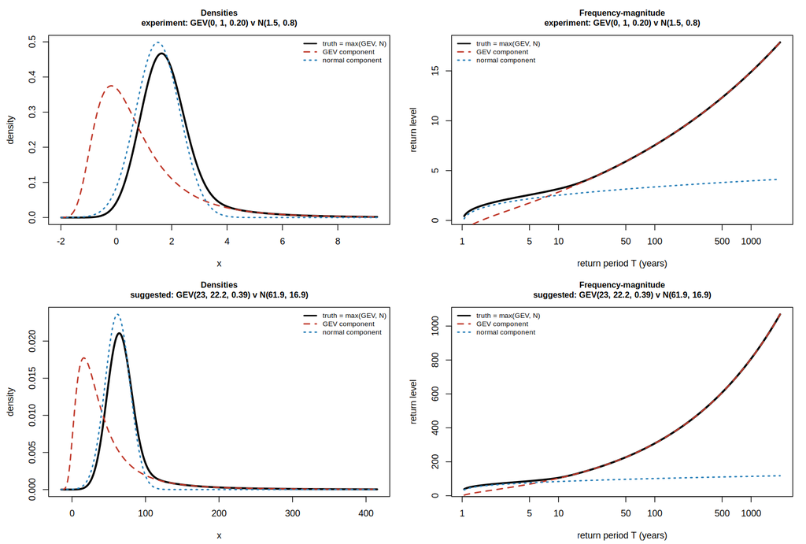

**The data-generating process.** Left, densities of the two components and of their maximum; right, the frequency–magnitude curves of all three. Top row, the setting used throughout; bottom, the heavier alternative. In both, the truth and its GEV component are indistinguishable beyond about T = 15, while the densities differ completely — the contamination is real, and it all lives in the body.

The second row is the alternative setting suggested as a check, GEV(23, 22.2, 0.39) against N(61.9, 16.9). It has a much heavier tail but, on the quantile scale, *milder* contamination: 2.5% at T = 10 against 11% here, and a mean ratio of 1.6 against 2.4. The setting used throughout is the more contaminated of the two.

### The weight function

A smoothstep, zero below p₀ and one above p₁. The primary design used p₀ = 0.95 and p₁ = 0.98, placed where the *quantile* contamination dies out (it leaves the quantiles 0.6% too high at p₀ and 0.00003% at p₁). Section 6 shows this choice, principled for L1, is badly wrong for L2, and section 5 sweeps it.

### Estimators and reporting

GEV by maximum likelihood; GEV by L-moments (Hosking); composite quantile (L1); composite expectile (L2). 2000 replicates at n = 50, 100 and 200, all four estimators fitted to identical datasets, so every comparison below can be made *paired* — which matters, because the sampling distribution of a far-tail return level is heavy-tailed and unpaired Monte Carlo error would swamp the differences at issue. Every ratio quoted carries a paired Monte Carlo standard error. The shape parameter is bounded to [−0.45, 0.90] for all four estimators alike.

## 03Expectiles are anchored to the mean

This is the finding that most constrains the idea, and it is specific to L2.

The p-quantile of the contaminated truth equals the p-quantile of its GEV component as soon as the normal's cdf reaches one. Quantiles are *tail-local*. Expectiles are not. The p-expectile solves

k · φ(x) + m − x = 0, k = (2p − 1)/(1 − p), φ(x) = E[(Y − x)<sup>+</sup>]

and while φ(x) for large x sees only the tail, the mean m sees everything — including the contaminated body. So the truth's expectiles differ from its GEV component's at *every* level, by an amount that decays only like (1 − p)<sup>ξ</sup>.

How much of the body contamination is still present in each functional. The quantile discrepancy reaches machine precision by the 50-year level; the expectile discrepancy is still 9.7% there, and 1.4% at 10 000 years.

| level p | return period | quantile still off by | expectile still off by |
| --- | --- | --- | --- |
| 0.95 | 20 yr | 0.56% | 16.0% |
| 0.98 | 50 yr | 0.00003% | 9.7% |
| 0.99 | 100 yr | ≈ 0 | 7.0% |
| 0.999 | 1000 yr | ≈ 0 | 2.9% |
| 0.9999 | 10 000 yr | ≈ 0 | 1.4% |

The consequence is structural: **there is no weight function that makes the composite expectile estimator asymptotically unbiased under body contamination**, whereas the composite quantile estimator is exactly unbiased. Fitting each estimator to a single sample of 2×10<sup>6</sup> gives the parameter each converges to, and hence the bias no sample size removes:

Asymptotic targets and the return-level bias they imply, at the primary weight (p₀ = 0.95). The tail-focused idea works exactly as intended — both composite estimators essentially eliminate the 20–40% bias that the global methods carry.

| estimator | μ | σ | ξ | bias at T = 100 | at T = 1000 |
| --- | --- | --- | --- | --- | --- |
| GEV maximum likelihood | 1.397 | 0.890 | 0.062 | −18.7% | −39.1% |
| GEV L-moments | 1.384 | 0.819 | 0.120 | −15.1% | −31.6% |
| Composite quantile (L1) | 0.011 | 0.999 | 0.200 | +0.02% | −0.08% |
| Composite expectile (L2) | 0.832 | 0.879 | 0.219 | +3.4% | +0.7% |
| true GEV tail | 0 | 1 | 0.20 | — | — |

L1 recovers the true tail parameters to three decimals. L2 lands a few percent away, and that gap is the mean-anchoring above.

## 04Return levels, and the price of unbiasedness

Bias is only half the account. The panels below show the sampling distribution of each estimator's return-level curve at n = 100, under the primary weight.

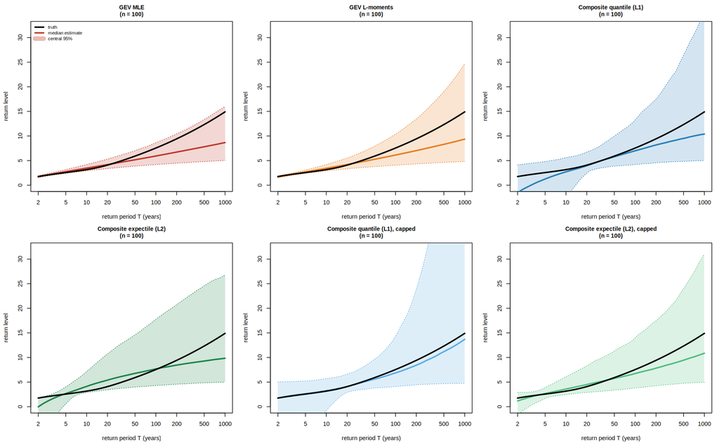

**Return period against return level, n = 100.** Solid black is the truth, the coloured line the median estimate, the band the central 95% of 2000 replicates. The two global methods are tight and bent; the composite estimators are centred and wide.

Maximum likelihood has a tight band whose centre flattens badly below the truth — the 20–40% bias of the previous section, visible as a curve that stops rising. The composite estimators track the truth far better in the median and pay for it in width. The two lower-right panels use a weight capped so that it does not extend past the largest observation (section 6); the capped L1 median follows the truth almost exactly to T = 1000, with a 95% band running from 5 to beyond 30.

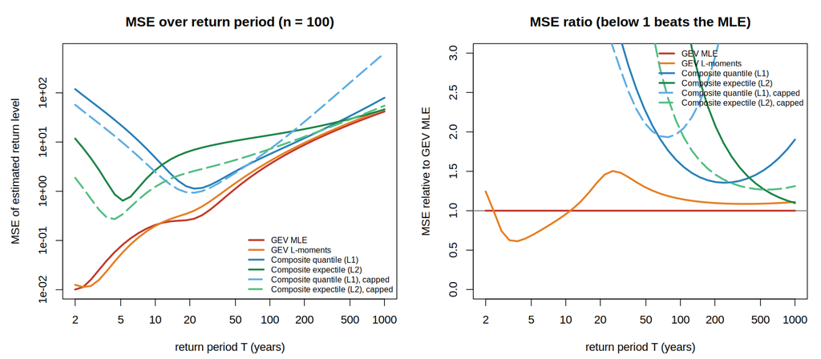

**Mean squared error over return period.** Left, absolute MSE; right, MSE relative to the GEV MLE, where below 1 would beat it. At this weight, nothing does beyond T = 20.

On mean squared error, at this weight, no composite design beats maximum likelihood anywhere from T = 20 to T = 1000. The trade each makes against the MLE at T = 1000, in MSE units, is the compact way to see why:

Bias–variance accounting for the 1000-year return level, n = 100. The true return level is 14.90.

| estimator | bias² | variance | MSE | bias² bought | variance paid |
| --- | --- | --- | --- | --- | --- |
| GEV maximum likelihood | 33.5 | 8.2 | 41.7 | — | — |
| Composite quantile (L1) | 3.2 | 76.1 | 79.3 | −30.3 | +67.9 |
| Composite expectile (L2) | 12.1 | 33.7 | 45.8 | −21.4 | +25.5 |

L1 pays 2.2 units of variance for every unit of squared bias it removes. L2 pays 1.2. **Switching to L2 turns a badly losing trade into a nearly even one** — which is the direction the L1-to-L2 argument predicts, and about half of the improvement needed.

## 05How much is the tail focus, and how much is L1 versus L2?

The previous section fixes the weight at one setting, which conflates two things: the choice of functional and the strength of the tail focus. Sweeping the lower edge p₀ from 0 (w ≡ 1, no tail focus at all) up to 0.95 separates them. At p₀ = 0 the composite quantile estimator is exactly CRPS minimisation, which is the like-for-like benchmark against L-moments: both are global, quantile-flavoured, and neither has any tail focus.

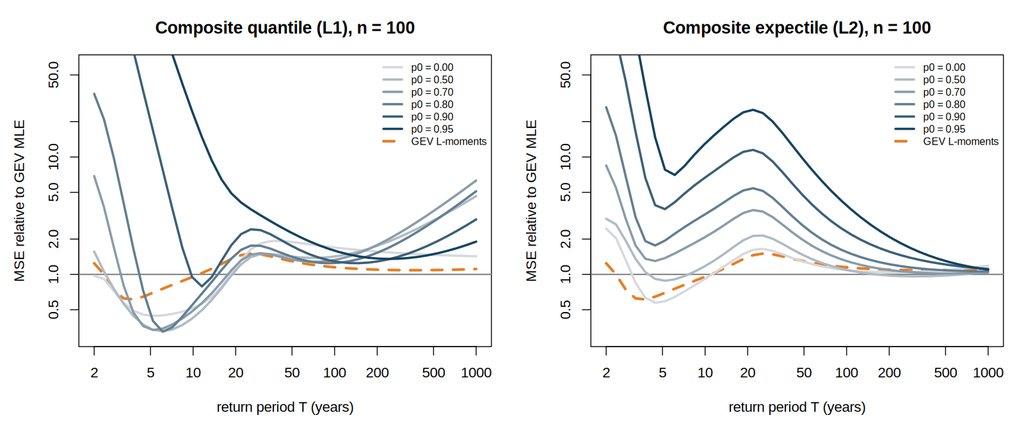

**Sweeping the tail focus.** MSE relative to the GEV MLE as the weight's lower edge moves from p₀ = 0 (w ≡ 1, palest) to 0.95 (darkest); dashed orange is GEV L-moments. Every expectile curve converges to about 1.05 in the far tail whatever the weight; every quantile curve diverges upward.

The two panels behave completely differently in the far tail. Every L2 curve converges to roughly 1.05 at T = 1000 whatever the weight; every L1 curve diverges upward, the worst of them to 6× the MLE. That contrast *is* the answer to the original question.

Paired comparison of the two losses at matched weight, same 2000 datasets: MSE(L2) / MSE(L1) for the 1000-year return level, with the Monte Carlo standard error of the paired difference. L2 wins decisively at every weight.

| weight starts at | MSE(L2) / MSE(L1) at T = 1000 | sd(L2) | sd(L1) |
| --- | --- | --- | --- |
| p₀ = 0 (w ≡ 1) | 0.83 ± 0.04 | 6.72 | 4.32 |
| p₀ = 0.50 | 0.23 ± 0.07 | 6.49 | 13.51 |
| p₀ = 0.70 | 0.17 ± 0.06 | 6.32 | 15.03 |
| p₀ = 0.80 | 0.21 ± 0.06 | 6.26 | 13.80 |
| p₀ = 0.90 | 0.38 ± 0.06 | 6.15 | 11.05 |
| p₀ = 0.95 | 0.58 ± 0.05 | 5.81 | 8.73 |

Two things stand out. First, L2's far-tail standard deviation is *almost invariant* to the weight (5.8 to 6.7 across the whole sweep) while L1's swings between 4.3 and 15.0. The expectile criterion is simply a much better conditioned thing to minimise under tail weighting, because expectiles are smooth functionals of the whole sample while quantiles lean on a handful of order statistics.

Second, the sign of the comparison flips at p₀ = 0. With no tail focus, the *quantile* version has the lower variance (ratio 0.83 in L2's favour on MSE, but sd 4.32 against 6.72 — L2 wins on MSE there only through bias). So the L2 advantage is not a general property of expectiles; it is specific to tail-weighted criteria, which is exactly where the proposal lives.

### Where the weight should start

The primary design put p₀ at 0.95, where the quantile contamination dies out. That is correct reasoning for L1 and wrong for L2 — section 3 showed the expectile contamination is still 16% there, so restricting to the extreme tail costs a great deal of data and buys almost no bias reduction. The sweep bears that out.

MSE relative to GEV MLE for the 1000-year return level, n = 100, with the Monte Carlo standard error of the paired difference. Ratios within about two standard errors of 1 are ties. This is a post-hoc sweep, not a pre-registered choice — read it as a sensitivity analysis.

| weight starts at | composite quantile (L1) | composite expectile (L2) | median ξ̂ (L2) |
| --- | --- | --- | --- |
| p₀ = 0 (w ≡ 1) | 1.43 ± 0.02 | 1.19 ± 0.05 | 0.162 |
| p₀ = 0.50 | 4.64 ± 0.36 | 1.05 ± 0.05 | 0.209 |
| p₀ = 0.70 | 6.31 ± 0.39 | 1.04 ± 0.05 | 0.164 |
| p₀ = 0.80 | 5.11 ± 0.33 | 1.06 ± 0.05 | 0.106 |
| p₀ = 0.90 | 2.94 ± 0.22 | 1.11 ± 0.05 | −0.029 |
| p₀ = 0.95 | 1.90 ± 0.13 | 1.10 ± 0.04 | −0.196 |
| GEV L-moments | 1.11 |  | 0.095 |
| GEV maximum likelihood | 1.00 (reference) |  | 0.054 |

With the weight switching on near the median, the composite expectile estimator becomes **indistinguishable from the GEV MLE on MSE across the whole far tail**. Following the p₀ = 0.50 fit across return periods, the ratio to the MLE is 1.07 ± 0.04 at T = 100, 0.98 ± 0.04 at T = 200, 0.98 ± 0.04 at T = 500 and 1.05 ± 0.05 at T = 1000. It never significantly beats it. But it ties it while carrying a quarter of its bias (−1.39 against −5.79 at T = 1000) and recovering the shape parameter almost exactly: median ξ̂ = 0.209 against a true 0.20, where the MLE returns 0.054 and L-moments 0.095.

Worth noting

An estimator that ties on MSE but recovers ξ correctly is not the same product as one that wins on MSE. If what a study needs is a defensible shape parameter and a return-level curve that does not flatten, that is a different and possibly more useful thing than a marginally smaller squared error.

## 06When is the family wrong enough for this to win?

Everything so far says the tail-focused estimators tie the MLE at best. The natural next question is whether that is a property of the method or of the test: is there a realistic truth whose tail bias is severe enough that a global fit *must* lose? Two attempts, one that failed instructively and one that worked.

### Making the family more wrong does not help by itself

The first attempt replaces max(GEV, Normal) with a *graft*: above a join level the truth IS the GEV, exactly, and below it the body is a different distribution carrying no information about the tail at all. That removes the leak in the max construction, where the GEV component still shapes the upper body and so hands a global fit some tail information for free. Hydrologically it is the standard mixed-population picture, and it fits the rain-on-snow story directly: in most years the annual maximum is an ordinary snowmelt peak from a much less variable process, and in the rest it is a rain-on-snow event from a genuinely heavy-tailed one.

With GEV(0, 1, 0.4) above the 90th percentile and a truncated normal below, maximum likelihood is 55% low at the 1000-year level — far worse than the 39% in the main setting. And every composite estimator does *worse* against it, not better: MSE ratios of 2.8 to 4.5 at T = 1000. The reason is that the heavier tail which inflates the MLE's bias inflates the composite estimators' variance at the same time. Their standard deviation at T = 1000 is 35 to 45 on a true return level of 37.

The governing ratio

To first order the fractional return-level error at large T behaves like log(T) times the error in ξ. So the contest is decided not by the size of the MLE's bias but by **(ξ<sub>true</sub> − ξ<sub>MLE</sub>) / sd(ξ̂<sub>composite</sub>)** — and that ratio is roughly constant in T, which is exactly why the MSE-ratio curves flatten out in the far tail. Heavier tails move both terms together. What is needed is a truth that drags the global fit's shape hard *while leaving a large, clean region for the weighted criterion to read*.

### A near-degenerate body does

The second attempt keeps the max construction and simply makes the normal much tighter and higher: max(GEV(0, 1, 0.2), N(2.5, 0.3)). Physically this is the sharper version of the same story — ordinary snowmelt maxima cluster tightly because they are set by a fairly repeatable snowpack, and the heavy tail is entirely rain-on-snow. Statistically it drags a global fit hard (the MLE converges to σ = 0.39 against a true 1, and is 49% low at the 1000-year level) while leaving every level above the median GEV-governed, so a tail-weighted criterion gets a clean and precise read: sd(ξ̂) = 0.099 for the expectile version.

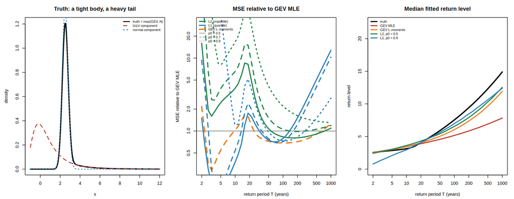

**A near-degenerate body.** Left, the truth: a tight normal at 2.5 with a heavy GEV tail. Middle, MSE relative to the GEV MLE for both losses at three weights. Right, the median fitted return-level curve — maximum likelihood flattens, the composite expectile fit tracks the truth.

Here the composite expectile estimator wins, and the composite quantile estimator does not:

max(GEV(0, 1, 0.2), N(2.5, 0.3)), n = 100, 2000 replicates, against the GEV MLE. Mean squared error is reported with its paired Monte Carlo standard error; because a handful of extreme replicates dominate it, the median absolute error and the head-to-head win rate on the same datasets are the more informative summaries.

| estimator | MSE ratio T = 200 | MSE ratio T = 1000 | median \|error\| ratio T = 200 | median \|error\| ratio T = 1000 | closer than the MLE T = 200 | closer than the MLE T = 1000 |
| --- | --- | --- | --- | --- | --- | --- |
| Composite expectile (L2), p₀ = 0.5 | 0.81 ± 0.15 | 1.10 ± 0.28 | 0.59 | 0.58 | 88% | 84% |
| Composite quantile (L1), p₀ = 0.5 | 1.54 ± 0.07 | 12.78 ± 0.50 | 0.75 | 1.79 | 68% | 38% |
| Composite quantile (L1), p₀ = 0.9 | 0.84 ± 0.05 | 2.82 ± 0.26 | 0.60 | 0.81 | 82% | 66% |
| GEV L-moments | 0.72 ± 0.02 | 1.26 ± 0.11 | 0.70 | 0.76 | 86% | 77% |
| GEV maximum likelihood | 1.00 | 1.00 | 1.00 | 1.00 | — | — |

On typical error the composite expectile estimator is **40% closer to the truth than the MLE at every return period from 100 to 1000**, and it is the closer of the two on **84% of datasets** at T = 1000. The composite quantile estimator does not share this at all — at T = 1000 it is worse than the MLE on the same criterion, winning only 38% of the time. So this setting cleanly separates the two losses, in L2's favour, in exactly the way the original hypothesis predicted.

Mean squared error is the one criterion that still calls it a tie at T = 1000 (1.10 ± 0.28). That is not a contradiction: the expectile estimator's error distribution has a small proportion of very poor replicates, and squared error is dominated by them. Which summary matters depends on whether an occasional large overestimate of a design flood is worse than a systematic underestimate of every one — and in flood frequency it usually is not.

## 07Which weight functions are admissible

The weight cannot be chosen freely, and there are two separate conditions — one on the weight, one on the distribution being fitted.

### The condition on the weight

Writing u = 1 − p, the population risk at level p decays as

quantile (L1): r <sub>p</sub> ~ u<sup>1 − ξ</sup> expectile (L2): r <sub>p</sub> ~ u<sup>1 − 2ξ</sup>

with the measured log-log slopes converging to these to three decimals as u → 0. So for a weight that blows up like w(p) ~ (1 − p)<sup>−a</sup>, the criterion is finite if and only if

quantile (L1): a < 2 − ξ expectile (L2): a < 2 − 2ξ

At ξ = 0.2 that is a < 1.8 and a < 1.6, so a weight going like 1/(1 − p) is admissible for both and 1/(1 − p)² for neither. Note the L2 threshold is the tighter of the two. Taking the worst case over the range where the quantile version is defined at all, ξ ↑ 1, gives a < 1 — which reproduces the L1 result reported in the original thesis work.

The weight used throughout this study is bounded — identically 0 below p₀ and identically 1 above p₁ — so it clears both conditions with room to spare at every shape the estimators visit. Nothing here requires a weight bounded by 1; that is simply what was used.

### The condition on the distribution — and this one separates L1 from L2

The quantile risk needs only a finite first moment, ξ < 1. The expectile risk needs a finite *second* moment, ξ < 1/2, because E[(e − Y)² 1{Y < e}] is infinite for every e once the variance is:

Population risk at p = 0.99 for a GEV truth, by shape parameter.

| ξ | quantile risk | expectile risk |
| --- | --- | --- |
| 0.30 | 0.146 | 1.914 |
| 0.45 | 0.285 | 24.799 |
| 0.50 | 0.364 | ∞ |
| 0.60 | 0.623 | ∞ |

No weight function repairs this — the criterion is +∞ at every θ. So the L2 version, taken literally, is undefined exactly in the heavy-tailed regime the method exists to serve. For flood frequency that is not a remote corner of the parameter space: the alternative setting examined here has ξ = 0.39.

The repair is standard: minimise the loss *difference* against a fixed reference function,

Σ <sub>i</sub> ∫ w(p) [ ρ <sub>p</sub>(y <sub>i</sub>, T(p|θ)) − ρ <sub>p</sub>(y <sub>i</sub>, T <sub>ref</sub>(p)) ] dp

which has the same minimiser and is finite whenever E|Y| < ∞. In this study ξ = 0.2, so the raw criterion is finite and nothing was needed — but it should be built in before the estimator meets anything heavier.

### The same condition, across every method here

The moment requirement is not peculiar to the composite estimators. But it splits into *three* different questions that are easy to run together, and running them together gives the wrong answer. Is the raw criterion finite? Is the target functional even defined? And does the estimator have the usual root-n limit? Each is a different power of the tail.

Write the loss as ρ<sub>p,a</sub>(y, t) = |p − I(y < t)| |y − t|<sup>a</sup>. The raw criterion needs E|Y|<sup>a</sup>. But the loss *difference* above is bounded by C(1 + |Y|<sup>a−1</sup>), and so is the estimating equation it differentiates to,

p E[(Y − t)<sup>a−1</sup>; Y > t] = (1 − p) E[(t − Y)<sup>a−1</sup>; Y < t]

so the functional is defined under E|Y|<sup>a−1</sup> < ∞ — one order cheaper. Squaring that score for the sandwich meat gives E|Y|<sup>2(a−1)</sup> for the root-n limit. Reading the three off a GPD tail with index 1/ξ:

What each method needs of the tail, for a GPD with shape ξ. The exponent a is the power in the loss: a = 1 is the pinball, a = 2 the asymmetric square, and intermediate a gives the L<sup>a</sup>-quantiles of section 14. Only the middle column decides whether the target exists; the first is repaired for free by the loss-difference form.

| method | raw criterion finite | functional defined | root-n asymptotics |
| --- | --- | --- | --- |
| GEV / GPD maximum likelihood | — | any ξ | ξ > −1/2 |
| L-moments and probability-weighted moments | ξ < 1 | ξ < 1 | ξ < 1/2 |
| Composite quantile (L1) | ξ < 1 | any ξ | any ξ |
| Composite L<sup>a</sup>, 1 < a < 2 | ξ < 1/a | ξ < 1/(a−1) | ξ < 1/(2(a−1)) |
| — at a = 1.5 | ξ < 2/3 | ξ < 2 | ξ < 1 |
| Composite expectile (L2) | ξ < 1/2 | ξ < 1 | ξ < 1/2 |
| α-elastile, any α > 0 | ξ < 1/2 | ξ < 1 | ξ < 1/2 |

Three things fall out. First, the quantile needs *nothing*: the raw ξ < 1 in its first column is an artefact of not recentring, and the pinball functional is defined for any tail at all. Second, the α-elastile buys no domain. It is a sum, finite only if both terms are, so every α above zero inherits the expectile's ξ < 1/2 for the root-n limit — mixing trades bias against variance *inside* that domain and cannot widen it. Third, and the reason the L<sup>a</sup> family is worth its own experiment rather than being folded into the elastile: it is the only continuous path off L1 that *does* widen the domain. At a = 1.5 the functional survives to ξ < 2 and the root-n limit to ξ < 1, against ξ < 1 and ξ < 1/2 for L2. So a is a dial on how much tail heaviness the method tolerates, and α is not.

L-moments and L2 have the same domain

Worth noting for the practitioner comparison: probability-weighted moment estimators are consistent for ξ < 1 and asymptotically normal only for ξ < 1/2 — exactly the composite expectile's two thresholds. Whatever else switching from L-moments to L2 costs, it costs nothing in admissible tail heaviness. The comparison in section 13 is like-for-like on this axis.

### A third trap: weight beyond the data

A weight left at one all the way to p = 1 puts a large share of its mass at levels *above the largest observation*. Out there the empirical quantile and expectile functions have both saturated at the sample maximum, so the loss can only pull the fitted tail down. The fitted shape parameter tracks that share almost exactly:

Median fitted shape against the share of the weight sitting above the largest observation, for the p₀ = 0.95 design. True ξ = 0.2. Both columns converge to it, so this is finite-sample behaviour, not a defect of the estimator.

| n | weight above the largest observation | median ξ̂, L1 | median ξ̂, L2 |
| --- | --- | --- | --- |
| 50 | 45% | −0.82 | −0.52 |
| 100 | 27% | −0.24 | −0.19 |
| 200 | 13% | −0.01 | −0.06 |
| 500 | 5% | 0.17 | 0.09 |
| 10 000 | 0.3% | 0.21 | 0.21 |

At n = 50 this pins 89% of L1 fits and 56% of L2 fits onto the shape bound. Capping the weight at p = 1 − 1/n fixes the shape (median ξ̂ moves from −0.26 to 0.19 for L1 and −0.20 to 0.06 for L2) — but for L1 it then *worsens* the far-tail MSE by an order of magnitude, because the downward drag had been acting as accidental shrinkage. L2 survives capping intact. Whatever else is done with the estimator, **the weight should not extend past where the data can speak**.

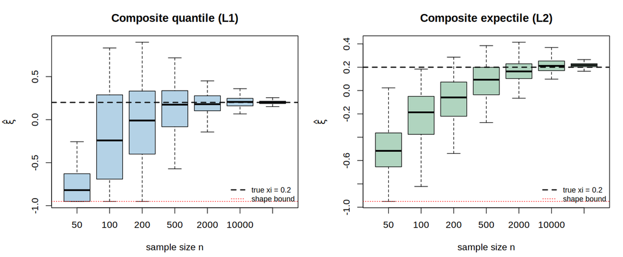

**Fitted shape against sample size**, with a wider shape bound than the main run so the bound itself cannot be the explanation. Both losses converge to the true ξ = 0.2; the small-sample bias is the extrapolation drag described above.

## 08Mixing the two losses: the α-elastile

The two losses fail in opposite directions — L1 unbiased and wild, L2 steadier and slightly biased — which invites an elastic-net-style compromise. Taking a convex combination of the two check functions at the same level,

ρ<sup>α</sup><sub>p</sub>(y, t) = (α/s) |p − I(y < t)| (y − t)<sup>2</sup> + (1 − α) (p − I(y < t)) (y − t)

gives a strictly consistent scoring function for a new functional — the **α-elastile**. Differentiating the expected loss identifies it as the unique root of

G(t) = (2α/s) [ (1 − 2p) φ(t) + (1 − p)(t − m) ] + (1 − α) [ F(t) − p ] = 0

The first bracket vanishes at the expectile, the second at the quantile, and both are increasing in t — so G is strictly increasing, the root is unique, and it always lies *between* the quantile and the expectile, which makes for a perfect bracket in the solver. α = 0 recovers the quantile and α = 1 the expectile.

The scale s carries units of y and is what makes α = 1/2 mean anything: without it the L2 term is in units of y² and the L1 term in units of y. It is fixed per dataset at the ratio of the two integrated losses evaluated at a preliminary L-moment fit, so the two contribute equally there. Being constant during the optimisation, it does not disturb the properness of the criterion; it only chooses the units in which α interpolates.

### The contamination interpolates smoothly

The reason to expect the mixture to help is that the structural obstacle of section 3 arrives gradually. The percentage by which the truth's functional exceeds its GEV component's — the contamination no weight can remove — runs smoothly from the quantile's zero to the expectile's:

Contamination surviving in the α-elastile of the contaminated truth, and the asymptotic return-level bias each α converges to.

| α | at T = 20 | at T = 50 | at T = 100 | at T = 1000 | asymptotic bias at T = 1000 |
| --- | --- | --- | --- | --- | --- |
| 0 (quantile) | 0.56% | 0.00% | 0.00% | 0.00% | −0.08% |
| 0.05 | 1.41% | 0.69% | 0.60% | 0.43% | +0.37% |
| 0.10 | 2.25% | 1.33% | 1.14% | 0.75% | +0.69% |
| 0.35 | 6.21% | 4.05% | 3.21% | 1.69% | +1.36% |
| 0.50 | 8.48% | 5.45% | 4.20% | 2.05% | +1.39% |
| 1 (expectile) | 15.99% | 9.73% | 7.03% | 2.89% | +0.70% |

So a small α keeps almost all of L1's asymptotic unbiasedness. The question is whether it also picks up L2's variance reduction, and it does — monotonically. At the good weight (p₀ = 0.5) and T = 1000, the standard deviation of the estimated return level falls from 13.51 at α = 0 to 6.49 at α = 1 without interruption, while the bias crosses zero around α = 0.2. That is exactly the configuration in which an interior optimum exists.

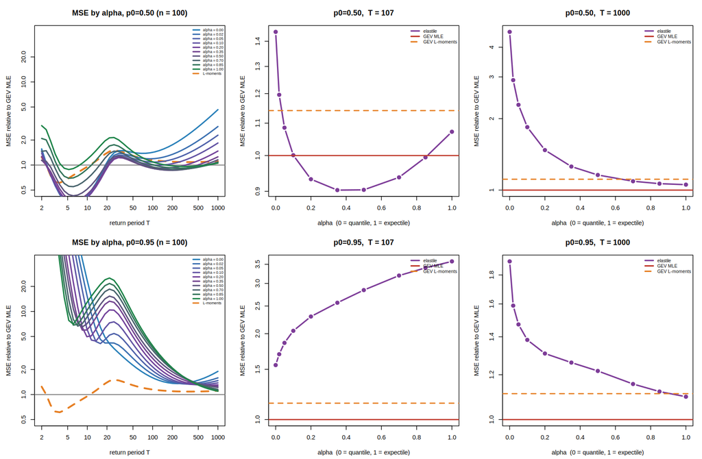

**The α-sweep.** Top row, the well-placed weight (p₀ = 0.5); bottom row, the original tail-focused one (p₀ = 0.95). Left, MSE against return period for each α; middle and right, MSE against α at T = 100 and T = 1000, with the GEV MLE and L-moments marked. The interior minimum at p₀ = 0.5 is the elastic-net effect; at p₀ = 0.95 it is largely absent.

α-sweep at p₀ = 0.5, n = 100, 2000 replicates. MSE relative to the GEV MLE. The best α is interior at every return period up to 500, and rises with T.

| α | T = 20 | T = 50 | T = 100 | T = 200 | T = 500 | T = 1000 |
| --- | --- | --- | --- | --- | --- | --- |
| 0 (pure L1) | 0.98 | 1.43 | 1.44 | 1.76 | 2.99 | 4.64 |
| 0.10 | 0.85 | 1.16 | 1.00 | 1.04 | 1.38 | 1.84 |
| 0.20 | 0.84 | 1.11 | 0.93 | 0.93 | 1.15 | 1.48 |
| 0.35 | 0.87 | 1.10 | 0.90 | 0.88 | 1.02 | 1.26 |
| 0.50 | 0.96 | 1.12 | 0.90 | 0.86 | 0.97 | 1.16 |
| 0.70 | 1.21 | 1.20 | 0.94 | 0.88 | 0.95 | 1.09 |
| 1 (pure L2) | 1.95 | 1.48 | 1.07 | 0.98 | 0.98 | 1.05 |
| GEV L-moments | 1.35 | 1.30 | 1.14 | 1.10 | 1.09 | 1.11 |
| gain over the better pure loss | 0.85 | 0.77 | 0.84 | 0.89 | 0.97 | 1.00 |

**Mixing helps, by 5 to 23% over whichever pure loss is better, and the optimal α rises with the return period** — from about 0.1 at T = 10 to pure L2 at T = 1000. That is the elastic-net pattern, and it has a clean reading here: the further out you extrapolate, the more the variance term dominates and the more of the expectile's smoothing you want.

Two caveats. The benefit depends on the weight being well placed: repeating the sweep at p₀ = 0.95 gives an interior optimum only at T ≤ 20, and the pure losses win everywhere beyond. And α is a tuning parameter, so a fair account of it needs the selection cost folded in — these are oracle values.

## 09Grafting the composite fit onto an empirical body

Everything above reports the composite fit as if it were the whole distribution, which is unfair to it and unlike how it would be used. The estimator buys its tail by abandoning the body, and the damage is severe: at p₀ = 0.95 the mean squared error of the 2-year return level is **eleven thousand times** the MLE's for the quantile version and a thousand times for the expectile version. That is not a subtlety, it is a ruined distribution.

The natural repair is to use the composite fit only as the *tail* of a smooth graft whose body is the empirical distribution. The construction used here is the hazard-mixture smooth graft (Coia and De Michele), taken from `probaverse/distplyr` rather than reimplemented, which mixes body and tail on the hazard rather than the density and so has no jump or kink at the handover and no normalising constant. Writing w for the handover weight and M = (1-w) S<sub>body</sub> + w S<sub>tail</sub>, the survival is S = M C with a correction factor C driven by w'.

With a weight that is exactly 0 below x<sub>lo</sub> and exactly 1 above x<sub>hi</sub>, the construction collapses to three regimes, which is worth spelling out because it explains the results:

- below x<sub>lo</sub>: w' = 0 so C = 1, and the graft *is* the empirical distribution;
- between: the transition, the only part needing the integral;
- above x<sub>hi</sub>: w' = 0 again, so C freezes at a constant c and S(x) = c · S<sub>tail</sub>(x) — the fitted tail, *rescaled by a single constant* that reconciles it with the body's mass at the handover.

That last point matters: the graft does not merely paste the fitted tail on, it re-anchors it. So one should expect the body to be fixed by construction, and the tail to change too.

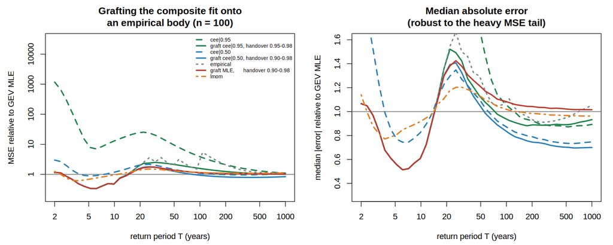

**Grafting repairs the body and improves the tail.** Dashed lines are ungrafted composite fits, solid lines the same fits used as the tail of a smooth graft with an empirical body. Left, MSE relative to the GEV MLE on a log scale — note the ungrafted p₀=0.95 expectile fit starting above 1000 at T = 2 and the grafted version sitting at 1.15. Right, median absolute error. The red line is the control: the MLE grafted onto the same body, which gains nothing.

Both expectations hold. The handover weight was run two ways — the same weight used in the fitting criterion, as proposed, and a fixed [0.90, 0.98] window — because the two weights do different jobs: one says which levels to fit, the other says where to stop trusting the data.

n = 100, 2000 replicates, MSE relative to the GEV MLE with paired Monte Carlo standard errors. No fits failed. The last two rows are the control: grafting a *global* fit onto the same body, to test whether any of the gain is simply the empirical body.

| fit used as the tail | T = 2 | T = 10 | T = 100 | T = 200 | T = 1000 | closer than MLE at T = 1000 |
| --- | --- | --- | --- | --- | --- | --- |
| Composite expectile p₀=0.95, *ungrafted* | 1168 ± 61 | 12.8 | 3.58 | 2.07 | 1.10 ± 0.04 | 63% |
| → grafted, handover 0.95–0.98 | 1.15 ± 0.03 | 0.47 | 1.52 | 1.24 | 1.01 ± 0.02 | 59% |
| Composite expectile p₀=0.50, *ungrafted* | 2.98 ± 0.08 | 1.17 | 1.07 | 0.98 | 1.05 ± 0.05 | 78% |
| → grafted, handover 0.90–0.98 | 1.15 ± 0.03 | 0.47 | 0.92 ± 0.02 | 0.82 ± 0.02 | 0.84 ± 0.03 | 80% |
| → grafted, handover 0.50–0.53 (same as fitting weight) | 1.15 | 1.89 | 1.32 | 1.20 | 1.34 ± 0.08 | 76% |
| Composite quantile p₀=0.50 → grafted, 0.90–0.98 | 1.15 | 0.47 | 2.01 | 2.46 | 6.38 ± 0.58 | 58% |
| Empirical distribution alone | 1.15 | 0.47 | 5.37 | 2.03 | 1.13 | 43% |
| GEV MLE → grafted, 0.90–0.98 *(control)* | 1.15 | 0.47 | 1.13 ± 0.01 | 1.07 ± 0.01 | 1.02 ± 0.01 | 50% |
| GEV L-moments → grafted, 0.90–0.98 *(control)* | 1.15 | 0.47 | 1.24 | 1.15 | 1.14 | 62% |

**The body is completely repaired.** Eleven thousand becomes 1.15, which is the empirical distribution's own figure — as it must be, since below the handover the graft is exactly the empirical distribution. The composite estimator's worst liability simply disappears.

The control settles it

Grafting the *MLE* onto the same empirical body gives 1.13, 1.07, 1.03, 1.02 and a 50% win rate — that is, nothing. Grafting L-moments is likewise neutral. So the gain is not the empirical body, and it is not the graft; it is the composite expectile tail, which only becomes usable once the graft takes the body off its hands. Neither ingredient works alone.

Two practical points. The handover weight should *not* be tied to the fitting weight: handing over at [0.50, 0.53] because the criterion was fitted from p₀ = 0.5 means trusting the parametric model from the 53rd percentile up, and costs a factor of 1.6 at T = 1000 against the decoupled [0.90, 0.98] version. And the graft does not rescue the L1 fit — grafted, the composite quantile estimator is still 6.4× the MLE at T = 1000. The tail model has to be worth grafting.

## 10Fixing the mean anchoring: it works, and it does not pay

Section 3 identified the one structural disadvantage L2 carries against L1: the expectile is anchored to the distribution's mean, so body contamination never fully leaves it. The identification equation splits cleanly, though —

k φ(x) + m − x = 0

— into a tail-local part (the partial moment φ, where a GEV fitted to a contaminated sample is right) and a global part (the mean, where it is not). So take the second from the data: replace the model's mean by the *sample* mean and leave φ as the model's. The mean becomes a nuisance parameter profiled out nonparametrically.

As a piece of statistics it works exactly as designed. The contamination surviving in the expectile at p = 0.98 falls from 9.73% to 0.0001%, and the estimator's asymptotic target moves onto the true tail parameters:

Asymptotic targets, fitted to a sample of 2×10<sup>6</sup>. The true tail is (0, 1, 0.20).

| estimator | μ | σ | ξ | bias at T = 100 | at T = 1000 |
| --- | --- | --- | --- | --- | --- |
| Composite expectile, p₀ = 0.95 | 0.836 | 0.872 | 0.220 | +2.86% | +0.51% |
| → mean-anchored | 0.026 | 0.989 | 0.202 | −0.32% | −0.23% |
| Composite expectile, p₀ = 0.90 | 1.006 | 0.797 | 0.237 | +1.22% | +0.25% |
| → mean-anchored | 0.161 | 0.953 | 0.208 | −0.49% | −0.26% |

The structural obstacle is gone: anchored, the L2 estimator is as asymptotically unbiased as L1.

And yet it is worse

At n = 100 the correction loses on every criterion at every return period. The median fitted shape goes from 0.209 (ordinary, p₀ = 0.5) to 0.079, and at p₀ = 0.95 it collapses to −0.45, the shape bound. Mean squared error at T = 1000 goes from 1.05 to 1.09 relative to the MLE; median absolute error from 4.68 to 4.81; the head-to-head win rate from 78% to 76%. Grafted, the ordinary version still wins (0.84× the MLE against 0.92×).

The reason is visible in the equation. An error δ in the anchor moves the solution by about δ/(1 + k S(x)), which for large p is essentially δ itself — the whole expectile curve translates by the sample mean's estimation error. Under a contaminated, heavy-tailed truth at n = 100 that error is not small, and it is injected at every level. Worse, the criterion must now reconcile a data-driven anchor with a model-driven φ, and when the weight is confined to the tail the model has little left to adjust except the shape — which is why ξ̂ is driven to its bound.

So this is a clean negative result, and it closes off the direction rather than opening it: the mean anchoring is real, the fix removes it exactly, and the fix is not worth its variance. If the idea is to be revived it needs a *low-variance* estimate of the anchor — a shrunk or model-averaged mean, or the mean of a trimmed body — not the raw sample mean.

## 11Where the handover should sit

Section 9 used a fixed [0.90, 0.98] handover on the grounds that the fitting weight and the handover weight do different jobs. Sweeping it further out tests that: if the empirical body is good, handing over later should be better.

It is not. Later is monotonically worse:

Composite expectile fitted at p₀ = 0.5, grafted onto an empirical body with the handover swept. MSE relative to the GEV MLE, n = 100, 2000 replicates, paired standard errors.

| handover | T = 20 | T = 50 | T = 100 | T = 200 | T = 500 | T = 1000 |
| --- | --- | --- | --- | --- | --- | --- |
| 0.90 – 0.98 | 1.47 | 1.28 | 0.92 ±0.02 | 0.82 ±0.02 | 0.80 ±0.03 | 0.84 ±0.03 |
| 0.95 – 0.99 | 1.79 | 1.71 | 1.16 | 1.00 | 0.95 | 1.00 ±0.04 |
| 0.97 – 0.995 | 1.79 | 1.94 | 1.43 | 1.81 | 1.83 | 2.00 ±0.13 |
| 0.99 – 0.999 | 1.79 | 1.93 | 1.81 | 2.33 | 2.32 | 2.51 ±0.18 |

The mechanism is the empirical distribution's own limit. Its quantile function saturates at the sample maximum, so it carries no information above about p = 1 − 1/n — 0.99 at n = 100. A handover that only *starts* at 0.99 leaves the graft relying on the empirical body across levels the empirical body cannot see, and the return-level curve flattens onto order statistics near the maximum long before the parametric tail is allowed to take over.

That gives a concrete design rule, and it is the mirror image of the one in section 7. The weight must not extend past where the data can speak; and the *handover* must complete before the empirical body runs out. With n observations, both point to the same place: finish the handover by roughly 1 − 2/n. At n = 100 that is 0.98, which is exactly where the best setting lands.

So the two weights should be decoupled, but not in the direction of pushing the handover later. The fitting weight can start anywhere the model is trustworthy; the handover is pinned near the top of the data by the sample size, not by the fit.

## 12Letting α depend on the level

Since the best α rises with the return period, the obvious next move is to let α depend on p. Does that still elicit anything?

**Yes, and the argument is short.** Properness here is a pointwise-in-p property. For each fixed level p, the mixed check function ρ<sup>α</sup><sub>p</sub> is strictly consistent for the α-elastile at that level, because the expected loss is strictly convex in the prediction with a unique minimiser. Nothing in that argument cares whether the α used at level p is the same as the one used at level p′. So for any measurable schedule α(·), the criterion

R(θ) = ∫ w(p) E[ ρ<sup>α(p)</sup><sub>p</sub>(Y, T(p|θ)) ] dp

is bounded below by the sum of the pointwise minima, with equality exactly when T(p|θ) = T<sub>α(p)</sub>(p; F) for w-almost every p. It is a strictly consistent scoring rule for the *curve* p ↦ T<sub>α(p)</sub>(p; F). Fisher consistency survives too: under correct specification over the weighted region, the truth's curve *is* the model's curve, for any schedule.

Three things are worth saying about what you get.

**The target is a hybrid.** Different points on the elicited curve are different functionals of F — the 0.2-elastile at p = 0.9, the 0.8-elastile at p = 0.999. That is perfectly well defined but it no longer has a name like "the expectile function", and any theory you would want to import (asymptotic variance for expectile regression, say) does not transfer without redoing it.

**Keep α(p) continuous.** This is the one real constraint, and it is not about properness — it is about attainability. A model's quantile, expectile and elastile curves are all increasing in p. The target curve need not be. In the tail the expectile sits *below* the quantile, so raising α pulls the target down while raising p pushes it up. With any continuous schedule tested — α = p, a smoothstep ramp over [0.9, 0.999], even α = 1 − (1−p)<sup>0.05</sup>, which is above 0.7 by p = 0.5 — the target stayed strictly increasing, at ξ = 0.2 and at ξ = 0.45. A schedule that *jumps* (α = 0 below p = 0.99, 1 above) makes the target fall by 1.27 at the jump. The criterion is still proper there; it is simply aiming at a curve no model can match, which is misspecification you have manufactured for yourself.

**It generalises further than α.** The same pointwise argument licenses letting *any* parameter of the level-p loss vary with p — the scale s included — and it is also why the composite construction tolerates a different loss family at each level. The cost is always the same: more tuning surface, and oracle-selected schedules that need their selection cost charged before the reported gains mean anything.

## 13A separate GPD study: against what a practitioner would actually do

Every comparison so far has been against methods that fit one parametric distribution to the whole sample. Faced with a body as obviously non-GEV as this one, nobody competent would do that. They would pick a threshold, fit a GPD to the exceedances, and hard graft it onto an empirical body. That is the right competitor, and it deserves its own comparison rather than being mixed in with the GEV work — so no GEV method appears in this section, and every ratio is against **POT–MLE at the 90th percentile, hard grafted**.

The composite version is the natural analogue: fit a three-parameter GPD to the whole sample with a weight that rises from p = 0, then smooth graft it onto the empirical body using that same weight as the handover. Here, unlike the GEV case of section 11, tying the two weights together is the natural choice rather than a mistake — the composite weight already starts at zero on the body, which is exactly where the empirical distribution should be trusted, so the two jobs coincide.

One caveat on the truth

max(GEV, Normal) has a tail that is exactly GEV, and a GEV tail is only *asymptotically* GPD: S = 1 − e<sup>−z</sup> against z, a relative error of about z/2, so roughly 5% at the 90th percentile and 0.5% at the 99th. The GPD is therefore mildly misspecified for every method in this section, which is realistic and affects them all alike.

### Threshold choice dominates the competitor

Before anything else: the practitioner's method is extremely sensitive to a choice it cannot make from the data. At T = 1000 the MSE of POT–MLE at thresholds 0.85, 0.90 and 0.95 is in the ratio 1.62 : 1.00 : 0.52 — a threefold spread from the threshold alone, with asymptotic biases of +20.6%, +8.8% and −1.7%. Switching from MLE to L-moments at the same threshold changes the MSE by a further factor of three. The composite estimator has no threshold; the weight plays that role, but it is a smooth choice rather than a discrete one.

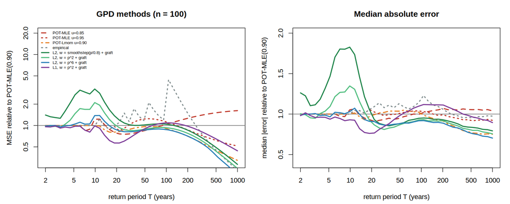

**The GPD study.** Left, MSE relative to POT–MLE(0.90) against return period; right, median absolute error on the same scale. Coloured solid lines are composite tail fits at three weights, grafted onto an empirical body; the dashed and dot-dashed lines are the practitioner's alternatives — the same POT–MLE at two other thresholds, POT–L-moments, and the raw empirical distribution. The w = p² and p⁶ composite fits fall away from the reference beyond about T = 200; the smoothstep weight pays for its late start in the 5- to 20-year band.

### Results

n = 100, 2000 replicates. All ratios against POT–MLE(0.90) hard grafted, with paired Monte Carlo standard errors. "w = p^6" rises from zero immediately but stays small on the body; "smoothstep(p/0.8)" is already substantially on by mid-distribution.

| method | T = 50 | T = 100 | T = 200 | T = 500 | T = 1000 | median \|err\| at T = 1000 | win rate at T = 1000 |
| --- | --- | --- | --- | --- | --- | --- | --- |
| POT–MLE, u = 0.90 *(reference)* | 1.00 | 1.00 | 1.00 | 1.00 | 1.00 | 6.78 | — |
| POT–MLE, u = 0.85 | 0.84 | 1.06 | 1.27 | 1.52 | 1.62 | — | 53% |
| POT–MLE, u = 0.95 | 1.24 | 1.10 | 0.86 | 0.61 | 0.52 ±0.07 | 6.26 | 51% |
| POT–L-moments, u = 0.90 | 0.95 | 0.94 | 0.79 | 0.49 | 0.32 ±0.07 | 5.09 | 73% |
| Empirical alone | 1.13 | 2.62 | 0.85 | 0.36 | 0.23 ±0.08 | 6.61 | 27% |
| Composite L2, w = smoothstep(p/0.8) + graft | 0.90 | 0.95 | 0.78 | 0.42 | 0.28 ±0.07 | 5.37 | 67% |
| Composite L2, w = p² + graft | 0.89 | 0.92 | 0.77 | 0.42 | 0.25 ±0.07 | 5.13 | 71% |
| **Composite L2, w = p⁶ + graft** | 0.86 ±0.02 | 0.87 ±0.02 | 0.70 ±0.03 | 0.36 ±0.06 | 0.21 ±0.07 | 4.77 | 77% |
| Composite L1, w = p² + graft | 0.89 | 1.09 | 0.97 | 0.63 | 0.44 ±0.07 | 6.07 | 59% |

Read the reference carefully

Grafting matters here as much as it did for the GEV. Ungrafted, the composite L2 GPD carries eight times the reference's error at the 2-year level; grafted, 0.98. And this is the case where reusing the fitting weight as the handover is right: it starts at zero on the body by construction, so it hands the body to the empirical distribution automatically.

### The elastile inside the GPD study

Sweeping α here reproduces the pattern of section 8, in the setting that matters most. The interior optimum is real at moderate return periods and the best α rises with T:

α-elastile GPD with w = p⁶, smooth grafted with the same weight. MSE relative to POT–MLE(0.90), n = 100, 2000 replicates. No fits failed.

| α | T = 20 | T = 50 | T = 100 | T = 200 | T = 500 | T = 1000 | median ξ̂ |
| --- | --- | --- | --- | --- | --- | --- | --- |
| 0 (pure L1) | 0.64 | 0.89 | 1.15 | 1.24 | 1.08 | 0.92 | 0.304 |
| 0.10 | 0.61 | 0.79 | 0.89 | 0.81 | 0.55 | 0.40 | 0.287 |
| 0.25 | 0.61 | 0.75 | 0.82 | 0.71 | 0.44 | 0.30 | 0.266 |
| 0.50 | 0.65 | 0.74 | 0.79 | 0.67 | 0.39 | 0.24 | 0.221 |
| 0.75 | 0.75 | 0.78 | 0.82 | 0.68 | 0.37 | 0.22 | 0.171 |
| 1 (pure L2) | 0.89 | 0.86 | 0.87 | 0.70 | 0.36 | 0.21 | 0.127 |
| gain over the better pure loss | 0.96 | 0.86 | 0.91 | 0.95 | 1.00 | 1.00 | — |
| POT–L-moments(0.90) | 0.81 | 0.96 | 0.88 | 0.70 | 0.44 | 0.32 | — |

Mixing buys up to 14% over the better pure loss at T = 50, tapering to nothing beyond T = 500 where pure L2 already wins. And α ≈ 0.5 is where the *shape* is best recovered: median ξ̂ = 0.221, against 0.304 at α = 0 and 0.127 at α = 1. The shape estimate and the MSE point at the same place, which they did not in the GEV study.

How much is left for a level-dependent alpha

Since the best α moves with T, the obvious next step is to let it move with p (section 12 shows that is proper). The ceiling is small: taking the best α separately at every return period — an oracle no schedule can beat — improves on the best *single* α (0.50) by **14% at the very far tail and 4.4% on average**. That is the entire prize available, before any cost of choosing the schedule.

### The other dial: L<sup>a</sup> at a = 1.5

The exponent in the loss is a second, independent way to sit between L1 and L2. Rather than adding the two check functions, raise the residual to a power a between 1 and 2 — the L<sup>a</sup>-quantiles. The two families share endpoints but are different curves in between: at p = 0.9 for GPD(0, 1, 0.2) the quantile is 2.925 and the expectile 2.875, while the 1.5-quantile is 2.747, *outside* the interval they span. So neither is a reparameterisation of the other and a result for one does not transfer. Run on the same 2000 replicates, against the same reference:

MSE relative to POT–MLE(0.90), n = 100, 2000 replicates, all grafted. Monte Carlo standard errors on these ratios are 0.014–0.072, rising with T.

| estimator | T=19 | T=48 | T=107 | T=203 | T=529 | T=1000 | win rate, T=1000 |
| --- | --- | --- | --- | --- | --- | --- | --- |
| POT–L-moments(0.90) | 0.81 | 0.96 | 0.88 | 0.70 | 0.44 | 0.32 | 0.73 |
| a = 1 (pure quantile) | 0.64 | 0.89 | 1.15 | 1.24 | 1.08 | 0.92 | 0.61 |
| a = 1.5 | 0.69 | 0.78 | 0.88 | 0.82 | 0.54 | 0.39 | 0.71 |
| a = 2 (pure expectile) | 0.89 | 0.86 | 0.87 | 0.70 | 0.36 | 0.21 | 0.77 |
| α-elastile, α = 0.5 | 0.65 | 0.74 | 0.79 | 0.67 | 0.39 | 0.24 | 0.74 |

The exponent dial is dominated by the mixing dial. At every one of the six return periods the α = 0.5 elastile beats a = 1.5, and in the far tail pure L2 beats it too — 0.21 against 0.39 at T = 1000. What a = 1.5 does have is the most *uniform* win rate of anything here, never dropping below 0.65 at any return period where L1 falls to 0.52 and L2 to 0.62; it is the safest single choice if the return period of interest is unknown. But it is nobody's optimum.

A caveat that runs in a = 1.5's favour

The closed form used for the upper fractional moment needs ξ > 0, so the a = 1.5 fitter is constrained to positive shape and **14.2%** of its fits sit pinned at that bound. The unconstrained fitters put 10–23% of their fits *below* zero, and since every fitter here underestimates ξ on average, censoring at zero prevents the worst underestimates rather than causing them. So the constraint flatters a = 1.5 — and it still loses to the elastile at every return period. Lifting it means integrating over the finite upper endpoint of a negative-shape GPD, which is straightforward but not done here.

Read with the moment conditions of section 7, this gives the two dials a clean division of labour. The exponent is the one that widens the domain — a = 1.5 keeps the root-n limit out to ξ < 1 where L2 stops at ξ < 1/2 — and buys little accuracy. The mixing weight buys the accuracy and widens nothing. For ξ = 0.325, comfortably inside both domains, there is no reason to reach for the exponent; for a tail heavy enough that L2 has no limit distribution, it is the only continuous route back to L1.

## 14Everything here is an M-estimator, and the elastile is an M-quantile

It is worth naming the framework these estimators already live in, because it supplies theory for free and it changes how the elastile should be positioned.

### The estimators

Every composite estimator in this report minimises a sum over observations of a criterion in θ,

θ̂ = argmin Σ <sub>i</sub> ρ̃(y <sub>i</sub>; θ), ρ̃(y; θ) = ∫ w(p) ρ <sub>p</sub>(y, T(p|θ)) dp

which is exactly Huber's M-estimator with a particular ρ̃. Maximum likelihood is the case ρ̃ = −log f. (L-moments is not an M-estimator but is a Z-estimator, solving λ̂<sub>r</sub> = λ<sub>r</sub>(θ), and the same asymptotics apply.)

The consequence is that standard M-estimation theory applies without modification. Under the usual conditions θ̂ is consistent for the population minimiser — the "asymptotic target" tabulated throughout this report — and asymptotically normal with the sandwich variance

V = A<sup>−1</sup> B A<sup>−1</sup>, A = E[∇²ρ̃], B = Var[∇ρ̃]

Two things follow that would otherwise cost simulation. Analytic standard errors and asymptotic relative efficiencies, so the choice of weight and of α can be studied without a Monte Carlo at every setting. And a diagnosis of the near-flat ridge that dominates the variance in section 5: that ridge is A being close to singular over the tail-weighted region, which says the remedy is a reparameterisation or a penalty in that direction rather than a different loss.

How flat that ridge is, measured

Flat enough that the "asymptotic target" figures in this report are not converged at the sample size used to estimate them. Refitting the same criterion to three independent n = 5000 samples gives ξ̂ = 0.149, 0.233 and 0.405 for the one-sided M-quantile of section 15, and 0.213, 0.259 and 0.354 for pure L2 — a spread of a quarter in the shape parameter, at fifty times the sample size of the study. The three decimal places these targets are quoted to are therefore misleading, and comparisons between one estimator's asymptotic target and another's should not be read at that resolution. The 2000-replicate medians are the reliable summaries throughout, and the return-level results, which average over the ridge rather than sitting on it, are unaffected. This is the same near-singular A, seen from a different direction.

### The functionals

The second sense of "M" is Breckling and Chambers' **M-quantiles**: the level-p M-quantile for an influence function ψ is the root of

E[ |p − I(Y < t)| ψ(Y − t) ] = 0

Every functional in this report is one of these, differing only in ψ:

The functionals as M-quantiles. The elastile row is verified against the definition to machine precision (residuals below 1e-11) in `scripts/98-validate.R`.

| functional | ψ(u) | influence | reference |
| --- | --- | --- | --- |
| Quantile | sign(u) | bounded | — |
| Expectile | u | unbounded | Newey & Powell (1987) |
| L<sup>a</sup>-quantile | \|u\|<sup>a−1</sup> sign(u) | unbounded for a > 1 | Chen (1996); Daouia, Girard & Stupfler |
| **α-elastile** | **(2α/s) u + (1−α) sign(u)** | unbounded for α > 0 | this report, as an M-quantile |
| Huber M-quantile | min(k, max(−k, u)) | bounded | Breckling & Chambers (1988) |

**So the α-elastile is not a new functional.** It is the M-quantile with a linear-plus-sign influence function, and it sits inside a framework that is thirty-five years old. That is worth saying plainly, and it is not a loss: positioning it as "a particular M-quantile, chosen because its identification equation needs only the first partial moment" is both honest and stronger than claiming novelty, because it inherits the existing asymptotic theory rather than having to rebuild it. What is genuinely new here is the *use* — a tail-weighted composite criterion built on it, and the finding that the mixing parameter has an interior optimum that moves with the return period.

The robustness logic inverts

M-estimation exists to bound the influence of outliers, and by that standard the quantile (ψ bounded) is the robust choice and the expectile (ψ unbounded) the fragile one. Every result in this report points the other way: L2 has one-half to one-sixth of L1's far-tail error. The reason is that in tail estimation the "outliers" *are the data* — the large observations carry nearly all the information about ξ, and a bounded ψ deliberately discards it. Whatever is inherited from robust statistics, the usual advice about bounded influence should be inverted when the target is the tail.

The right word is tail-robustness, and there is prior art

Two literatures answer to "robust" here and only one of them is this one. The first applies classical robustness to extreme value models — Dupuis's optimal B-robust estimator for the GPD, and the minimum density power divergence estimator, which is indexed by a constant running from the MLE at zero to bounded influence above it. That family is structurally the elastile's twin — one dial from efficient to robust — but it runs the other way: it downweights large observations as contamination, where everything here upweights them as signal.

The second literature is the relevant one, and it is thinner. It calls the problem *tail-robustness*: contamination in the body corrupts the tail extrapolation, so weight the fit towards the tail. Fung's maximum weighted likelihood estimator (*Insurance: Mathematics and Economics* **107**, 180–198, 2022; arXiv:2108.01356) proves the tail index remains consistent under model misspecification for a weighted likelihood, motivated by insurance claim severities rather than floods. That is prior art for this report's core claim, and the framing to adopt: saying "robust" unqualified invites the Dupuis/MDPDE reading and the objection that ψ here is unbounded. What is not in that work is the composite integration over *levels* rather than observations, the L2 and mixed-loss families, and the finite-sample accounting of section 16.

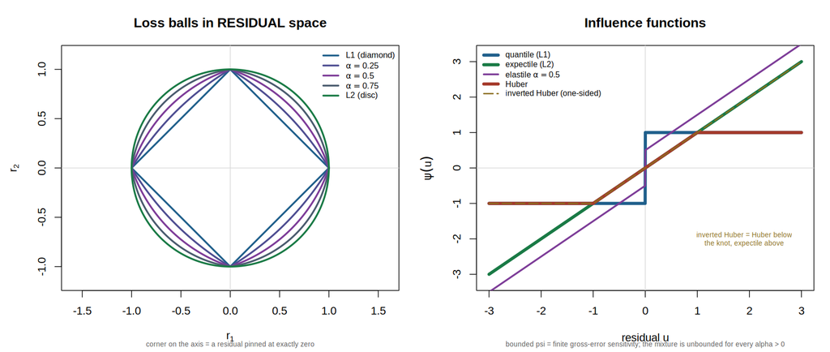

**Where the elastic-net picture does and does not transfer.** Left, the elastic net's diamond-and-circle diagram is about a *penalty*'s level set in coefficient space, where a corner means a coefficient pinned at zero. Built instead in *residual* space, the set of r with Σ ρ(r <sub>i</sub>) ≤ 1 gives the same shapes — and its corner means a *residual* pinned at zero, which is L1 regression's classical exact-fit property. Right, the picture that actually governs a loss. The elastile's ψ is unbounded for every α > 0, so it has infinite gross-error sensitivity; Huber's splice does not, which is why robust statistics took the splice and never the mixture.

One caveat about which path to take between L1 and L2. The elastile and the L<sup>a</sup> family share endpoints but are different curves: at p = 0.9 for GPD(0, 1, 0.2) the quantile is 2.925 and the expectile 2.875, while the 1.5-quantile is 2.747 — outside the interval they span. So the two are not reparameterisations of one another, and a result for one does not transfer to the other.

## 15Inverting the knot: capping the downside

If bounded influence is the wrong instinct here, the obvious move is to invert Huber's knot: constant influence where Huber is linear, linear influence where Huber is bounded. Two inversions are possible and they are not the same estimator.

(A) symmetric ψ(u) = sign(u) max(|u|, c) (B) one-sided ψ(u) = max(u, −c)

(A) bounds the influence of observations *near* the fitted level and lets it grow on both sides. (B) is what the argument above actually asks for: linear above the fitted level, capped below it, because it is the downside that carries the contaminated body. Both reduce to closed forms in the partial moment φ(x) = E[(Y − x)<sup>+</sup>] the earlier sections already provide, so neither needs quadrature:

(A) p [c S(t) + φ(t+c)] = (1−p) [c F(t) + (t−c) − m + φ(t−c)] (B) p φ(t) = (1−p) [c + φ(t) − φ(t−c)]

(B) is the interesting one, for a reason visible in the second line. The two mean terms cancel between φ<sub>L</sub>(t) and φ<sub>L</sub>(t−c), so its identification equation contains no model mean at all. **Capping the downside removes the mean anchoring structurally**, where section 10 had to substitute a noisy sample mean for it and lost at n = 100. Both closed forms were checked to 1e−13 against a kink-split reference quadrature at ξ = 0.1, 0.325 and 0.6. The limits hold exactly: (A) runs expectile → quantile as c goes 0 → ∞, non-monotonically, overshooting past the quantile near c = 10; (B) runs from the expectile (c → ∞) to a degenerate limit at the upper endpoint (c → 0), so it never reaches the quantile.

### The contamination, measured honestly

A first pass showed (B) shedding *all* the body contamination at every level — better than the quantile, which would have been too good. It was. At c = 0.1 the nominal p = 0.90 functional sits at t = 11.29, which is the 0.99728 quantile: small c does not shed the contamination, it outruns it. Comparing at matched *effective* level F(t) instead:

Surviving body contamination, 100(T<sub>truth</sub>/T<sub>GEV</sub> − 1), read at matched effective level rather than matched nominal p. Zero means the body has been shed entirely.

| functional | u = 0.95 | u = 0.99 | u = 0.999 |
| --- | --- | --- | --- |
| quantile | 0.569 | 0.000 | 0.000 |
| expectile | 15.726 | 5.480 | 2.302 |
| (B) one-sided, c = 0.25–0.5 | 0.000 | 0.000 | 0.000 |
| (B) one-sided, c = 1 | 0.203 | 0.000 | 0.000 |
| (A) symmetric, c = 8 | 0.567 | 0.293 | 1.875 |

The result survives the fair comparison. At small c the one-sided M-quantile gives quantile-or-better contamination *while keeping fully linear upside influence* — the combination section 3 said was unavailable. (A) only sheds contamination as it converges to the quantile, which is already in this comparison as α = 0, so it is not pursued further.

### And then n = 100

Which is where section 10's lesson repeats itself. The knot is set as c = k × IQR(y), fixed from the data before optimising so that ρ does not move with θ. Same 2000 datasets, same weight, same graft, same reference as sections 8 and 13.

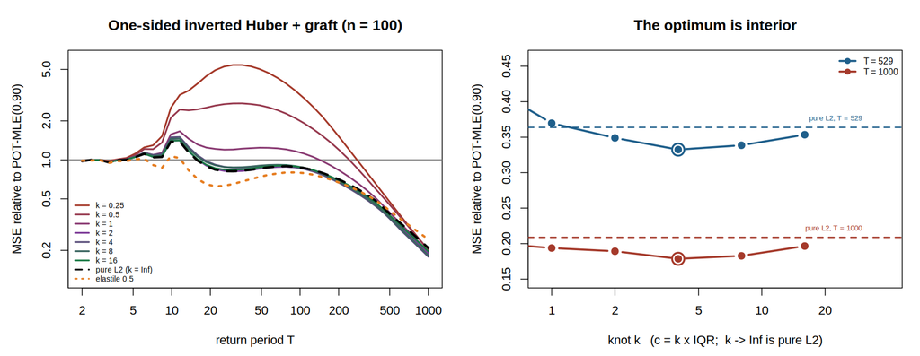

**The knot sweep.** Left, MSE relative to POT–MLE(0.90) against return period, for knots from k = 0.25 to 16, with pure L2 (the k → ∞ limit) dashed in black and the α = 0.5 elastile dotted in orange. Small knots are catastrophic below T = 200 and the damage is section 7's third trap. Right, the same numbers read along k at two long return periods: the optimum is interior at k = 4, circled, and the curve turns back up towards the pure-L2 dashed line on either side.

MSE relative to POT–MLE(0.90), n = 100, 2000 replicates, all grafted. k → ∞ recovers pure L2 exactly, so that row is this family's own limit. The t values are paired against pure L2 on the same datasets; negative favours the inverted Huber.

| knot | T=19 | T=48 | T=107 | T=203 | T=529 | T=1000 | median ξ̂ |
| --- | --- | --- | --- | --- | --- | --- | --- |
| k = 0.25 | 4.440 | 5.023 | 2.993 | 1.490 | 0.441 | 0.201 | −0.176 |
| k = 0.5 | 2.532 | 2.641 | 1.919 | 1.183 | 0.422 | 0.201 | 0.014 |
| k = 1 | 1.244 | 1.241 | 1.118 | 0.825 | 0.370 | 0.194 | 0.095 |
| k = 2 | 0.903 | 0.855 | 0.855 | 0.681 | 0.349 | 0.189 | 0.095 |
| k = 4 | 0.977 | 0.888 | 0.850 | 0.662 | 0.332 | 0.179 | 0.108 |
| paired t against L2 | +14.5 | +7.2 | −5.8 | −12.2 | −12.5 | −11.2 | — |
| k = 8 | 0.960 | 0.903 | 0.870 | 0.678 | 0.339 | 0.183 | 0.124 |
| k = 16 | 0.917 | 0.877 | 0.869 | 0.692 | 0.353 | 0.197 | 0.127 |
| pure L2 (k = ∞) | 0.894 | 0.859 | 0.866 | 0.702 | 0.364 | 0.209 | 0.127 |
| α-elastile, α = 0.5 | 0.649 | 0.740 | 0.790 | 0.666 | 0.388 | 0.243 | 0.221 |

**k = 4 is the best far-tail estimator in this report.** At T = 1000 it reaches 0.179 against a previous best of 0.209, and it beats pure L2 at every return period from T = 107 to 1000 with paired t between −5.8 and −12.5. Against the α = 0.5 elastile it wins at T = 529 and 1000 (t = −8.7 and −10.4), ties at 203 and loses at 107. The optimum is genuinely interior — k = 4 beats k = ∞, and the curve turns back up at k = 8 and 16 — so this is not "get as close to L2 as possible". It is also wide rather than a knife edge: even k = 16 still beats L2 at T = 1000 with t = −7.9.

Three qualifications, all against the derivation

**The mechanism is not what wins.** The theory predicted less bias. Finite-sample the bias is *worse*: −2.55 at T = 1000 for k = 4, against −1.94 for pure L2 and −0.76 for the elastile. It is more biased and wins on variance. At n = 100 the return-level bias is dominated by shape underestimation — median ξ̂ = 0.108 against a true 0.2 — which swamps the asymptotic contamination entirely.

**The regime where the theory helps is the regime the data cannot support.** Contamination vanishes at c ≤ 0.5, which is k = 0.25 to 0.5, and those give MSE ratios of 4.44 and 2.53 at T = 19. Section 7's third trap predicted it: at k = 0.25 fully **10.1%** of the fitting weight lands above the largest observation, against 0.8% for pure L2, and the median fitted shape duly collapses to −0.176.

**The useful regime is close to the expectile.** Since k → ∞ is pure L2, k = 2 to 4 is a mild downside cap on L2, not the body immunity the population result advertised.

So the verdict is narrower than the derivation promised: a mild cap on the downside is the best far-tail estimator here, and the mean-anchoring argument that motivated it is not the reason. That is still worth having — the interior optimum is real, decisive and stable over a wide range of k — but it belongs in a paper as an empirical finding with a suggestive derivation attached, not as a theoretical result confirmed by simulation. The gap between the two is the same gap as between sections 3 and 10: an obstacle that is genuine asymptotically and invisible at the sample sizes flood frequency actually has.

## 16The honest test: when nothing is wrong

Every result so far is on a misspecified truth, where a tail-weighted criterion has misspecification to avoid. If the data really are iid from the fitted family, maximum likelihood is efficient and every estimator here is throwing information away on purpose. It should lose. The size of that loss is the insurance premium, and without it none of this is deployable.

### An exactly correct GEV

iid GEV(0, 1, 0.2), n = 100, 2000 replicates, the weight starting at the median as section 5 recommends. The GEV MLE is now exactly right, so every ratio above one is what the method costs.

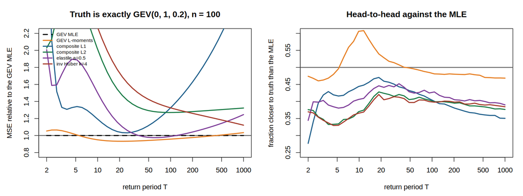

MSE relative to the GEV MLE on data that really are GEV. Above 1 is the price paid.

| estimator | T=2 | T=10 | T=48 | T=107 | T=203 | T=529 | T=1000 | median ξ̂ |
| --- | --- | --- | --- | --- | --- | --- | --- | --- |
| GEV L-moments | 1.05 | 0.95 | 0.94 | 0.96 | 0.98 | 1.01 | 1.03 | 0.184 |
| composite L1 | 3.68 | 1.20 | 1.11 | 1.35 | 1.64 | 2.24 | 2.83 | 0.167 |
| composite L2 | 2.03 | 2.03 | 1.30 | 1.27 | 1.28 | 1.31 | 1.32 | 0.095 |
| α-elastile, α = 0.5 | 2.01 | 1.51 | 0.98 | 0.99 | 1.04 | 1.15 | 1.25 | 0.122 |
| inverted Huber, k = 4 | 2.47 | 2.28 | 1.43 | 1.32 | 1.26 | 1.18 | 1.12 | 0.085 |
| GEV MLE (truth ξ = 0.2) | 1.00 | 1.00 | 1.00 | 1.00 | 1.00 | 1.00 | 1.00 | 0.198 |

Three things. **The body is where it hurts**: every composite estimator is 2 to 3.7× the MLE's error at T = 2, which is the weight doing exactly what it was told to do in a setting where the body was informative. **The far-tail premium is modest for two of them** — 12% for the inverted Huber and 25% for the elastile at T = 1000, against 32% for pure L2. And **L1 gets worse with return period rather than better**, 1.11 at T = 48 rising to 2.83 at T = 1000: the variance explosion appears even with no misspecification to justify it, so L1 has no defensible regime here at all. L-moments meanwhile ties the MLE across the board, the known result at this sample size and a check that the harness is not flattering anything.

The bias runs the unsafe way

At T = 1000 the MLE is biased +1.01 and L-moments +0.45, while L2 is −1.52, the elastile −1.03 and the inverted Huber −1.93. The composite estimators *under*-predict the far tail, which for flood design is the dangerous direction. The cause is in the last column: median ξ̂ is 0.198 for the MLE against 0.095 for L2 and 0.085 for the inverted Huber, on a true 0.2. Tail-weighted fitting underestimates the shape badly at n = 100 even when the family is perfect, and a low shape shrinks the far-tail extrapolation.

### An exactly correct GPD, done properly

The first version of this test drew from GPD(1, 0.5, 0.2) and fitted three parameters. That was wrong twice. A three-parameter GPD with unknown threshold is non-regular — the likelihood rises monotonically in μ up to min(y), so μ̂ is a boundary estimate — and, worse for the comparison, the reference was handed the true threshold while the composite estimators had to estimate it, so they were paying for a parameter the reference got free. A GPD used as a tail model has no location to estimate anyway: it starts at the threshold, and only scale and shape are unknown. So: iid GPD(0, 0.5, 0.2), μ known, two parameters for every method including the references, on a regular problem where the MLE is efficient.

Return periods need the exceedance rate

Here the GPD *is* the whole distribution, so exceedance probability 1/T is a T-year level and the labels below are self-consistent. Attached above a threshold with exceedance rate ζ, the T-year level solves ζ S(x) = 1/T, so a column labelled T is the **(T/ζ)-year** level: with ζ = 0.1 the column marked T = 100 is the 1000-year return level. No ratio changes — but the practically interesting range moves an order of magnitude left, into the middle of the table rather than its right edge.

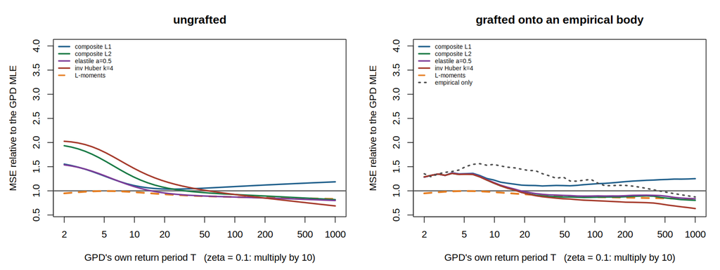

**And on a correctly specified GPD, fitted as a GPD.** Threshold known, so only scale and shape are estimated, by every method. Left, ungrafted: the composite fits are 1.5–2.0× the MLE at T = 2 because the weight neglected the body. Right, grafted onto an empirical body, which brings them all to about 1.29 there — the same value for four different tail models, and close to the empirical distribution's own 1.35 (dotted), because the body is doing the work. The dashed orange line is L-moments, which beats the MLE throughout.

MSE relative to GPD *L-moments*, which beats the MLE at every return period here (0.83 to 1.00, the known small-sample result for the GPD) and is therefore the honest yardstick. All rows grafted. Below 1 is better than L-moments.

| estimator | T=2 | T=5 | T=10 | T=26 | T=48 | T=107 | T=1000 |
| --- | --- | --- | --- | --- | --- | --- | --- |
| ζ = 0.1 → true return period | 20 | 52 | 98 | 256 | 484 | 1074 | 10000 |
| GPD MLE | 1.06 | 1.00 | 1.03 | 1.09 | 1.12 | 1.15 | 1.20 |
| empirical distribution alone | 1.43 | 1.51 | 1.59 | 1.55 | 1.44 | 1.33 | 1.05 |
| composite L1 | 1.36 | 1.36 | 1.26 | 1.21 | 1.25 | 1.32 | 1.51 |
| composite L2 | 1.36 | 1.35 | 1.19 | 1.00 | 0.98 | 1.00 | 0.97 |
| α-elastile 0.5 | 1.35 | 1.36 | 1.21 | 1.03 | 1.02 | 1.03 | 1.01 |
| inverted Huber k = 4 | 1.36 | 1.35 | 1.19 | 0.98 | 0.94 | 0.91 | 0.76 |

What the short-return-period numbers were measuring

At T = 2 the four grafted fits give 1.284, 1.288, 1.283 and 1.289 against the MLE. Four completely different tail models returning the same number is the signature of the empirical body doing all the work, and the empirical distribution on its own gives 1.353 there. So that column is the empirical distribution's performance against a parametric fit, not the loss function's, and it should not be read as a cost of the composite criterion. It is a cost of grafting. The ungrafted GEV numbers above are a different matter — there is no empirical body in that study at all, so their 2–3.7× really is the weight discarding the body.

The bias still runs the unsafe way: at T = 1000, −0.69 for the inverted Huber and −0.44 for L2, against +0.23 for the MLE and +0.37 for L-moments. Median fitted ξ is 0.124 to 0.172 against a true 0.2.

What this does to section 13

Section 13 reports the composite L2 graft at an MSE ratio of **0.209** against POT–MLE(0.90) at T = 1000 on the contaminated truth. The identical comparison — same estimator, same three-parameter fit, same reference — with *no misspecification at all* gives **0.344**. On a log scale that is **68% of the headline gain present with a perfect model**, only 32% from the misspecification the method exists to exploit. The reference keeps ten exceedances out of a hundred observations. The result stands, but most of the margin is data efficiency, and the paper should say so rather than leave it to be extracted.

**The recommendation.** With no evidence of misspecification, use L-moments. On a correct GEV the composite estimators cost 12–32% in the far tail and 2–3.7× in the body; on a correct GPD they cost nothing in the far tail — the one-sided estimator reaches 0.63 against the MLE at T = 1000 — and the cost is confined to short return periods. The two studies disagree because the fitting setups differ, so neither number is *the* premium. In both, though, the estimators lean unsafe. What justifies them is the misspecified case, where they cut error by half to six-fold. The first question is not which loss to use but whether the body model is wrong — and section 2's argument is that for rain-on-snow, with an ordinary-snowmelt population sitting under a rain-driven tail, it usually is.

## 17What each estimator converges to above a threshold

Everything so far compares estimators at a fixed sample size. A cleaner question is what each converges to with unlimited data. Fit a GPD to exceedances over u = 3.16, the truth's 0.90-quantile, and every estimator has a pseudo-true limit: the GPD minimising its own population criterion against the truth's conditional law. Those limits differ, and the differences are the argument for the method with the sampling noise removed.

The natural target comes from threshold stability. If exceedances over u₀ are GPD(σ₀, ξ) then exceedances over any u ≥ u₀ are GPD(σ₀ + ξ(u − u₀), ξ): shape invariant, scale linear in the threshold. For a GEV(μ, σ, ξ) tail, S(x)/S(u) tends to a GPD with shape ξ and scale σ + ξ(u − μ) as u grows, so carrying that limit back to the threshold in use gives **scale 1.6323, shape 0.2000**. The construction checks out: the truth's conditional survival matches it to a maximum log-ratio of 9.7×10<sup>−3</sup> at u = 6 and 2.7×10<sup>−7</sup> at u = 100.

### The limits, derived rather than simulated

Estimating these by fitting to a very large sample is not precise enough — the composite estimators separate by about as much as the seed-to-seed noise. They can be solved instead. Differentiating the composite criterion in θ, where the indicator contributes nothing because ρ is continuous at zero, the pseudo-true θ* solves

g <sub>p</sub><sup>G</sup>(t) = E <sub>G</sub>[ |p − I(Y < t)| ψ(Y − t) ] = p E <sub>G</sub>[ψ(Y−t) I(Y>t)] + (1−p) E <sub>G</sub>[ψ(Y−t) I(Y<t)]

Write g<sub>p</sub><sup>G</sup> for the M-quantile identification function of an arbitrary distribution G. The model's level-p functional T<sub>p</sub>(θ) is defined by g<sub>p</sub><sup>F θ</sup>(T<sub>p</sub>(θ)) = 0. Then the pseudo-true θ* solves

∫₀¹ w(p) g <sub>p</sub><sup>F</sup>(T <sub>p</sub>(θ)) ∇ <sub>θ</sub>T <sub>p</sub>(θ) dp = 0 ∇ <sub>θ</sub>T <sub>p</sub>(θ) = − [∂g <sub>p</sub><sup>F θ</sup>/∂θ] / [∂g <sub>p</sub><sup>F θ</sup>/∂t] at t = T <sub>p</sub>(θ)

The same function g appears twice, evaluated at two different distributions. At the *model* it defines the functional and, by implicit differentiation, its sensitivity. At the *truth* — the highlighted term — it measures the discrepancy: g<sub>p</sub><sup>F</sup>(t) vanishes exactly when t is the truth's own level-p M-quantile. So θ* sets a weighted average of the level-by-level discrepancies to zero, weighted by w(p) and by the sensitivity. Two consequences follow at once: the target depends on the weight, and it depends on ψ only through which functional is being matched.

Everything is elementary once the truth's distribution function F and partial moments Φ̄(t) = E[(Y − t)<sup>+</sup>] and Φ(t) = E[(t − Y)<sup>+</sup>] are available, using Φ(t) = t − E[Y] + Φ̄(t) above the lower endpoint and Φ(t) = 0 below it:

quantile ψ(v) = sign(v) g <sub>p</sub>(t) = p − F(t) expectile ψ(v) = v g <sub>p</sub>(t) = p Φ̄(t) − (1−p) Φ(t) elastile ψ(v) = (2α/s)v + (1−α)sign(v) g <sub>p</sub>(t) = (2α/s)[p Φ̄ − (1−p)Φ] + (1−α)[p − F(t)] one-sided ψ(v) = max(v, −c) g <sub>p</sub>(t) = p Φ̄(t) − (1−p)[Φ(t) − Φ(t−c)]

For the composite quantile fitted to GPD(0, σ, ξ) exceedances the whole system collapses to something writable. With T<sub>p</sub> = σ[(1−p)<sup>−ξ</sup> − 1]/ξ one has ∂T/∂σ = T/σ, and eliminating that equation from the second leaves the pair

∫₀¹ w(p) [p − F(T <sub>p</sub>)] T <sub>p</sub> dp = 0 ∫₀¹ w(p) [p − F(T <sub>p</sub>)] (1−p)<sup>−ξ</sup> log[1/(1−p)] dp = 0

two explicit integral equations in (σ, ξ). Solving them directly recovers (1.38035, 0.25484), the same root the general system gives, to five significant figures. For the expectile the model functional has no elementary form — it is the root of k φ<sub>θ</sub>(t) + m<sub>θ</sub> − t = 0 with k = (2p−1)/(1−p) — but implicit differentiation of that equation still gives ∇<sub>θ</sub>T in closed form, and it agrees with central differences to 2.5×10<sup>−10</sup>.

Solved to a residual below 10<sup>−10</sup>, with the two references obtained exactly as well (the likelihood limit minimises Kullback–Leibler divergence, the L-moment limit matches the first two L-moments):

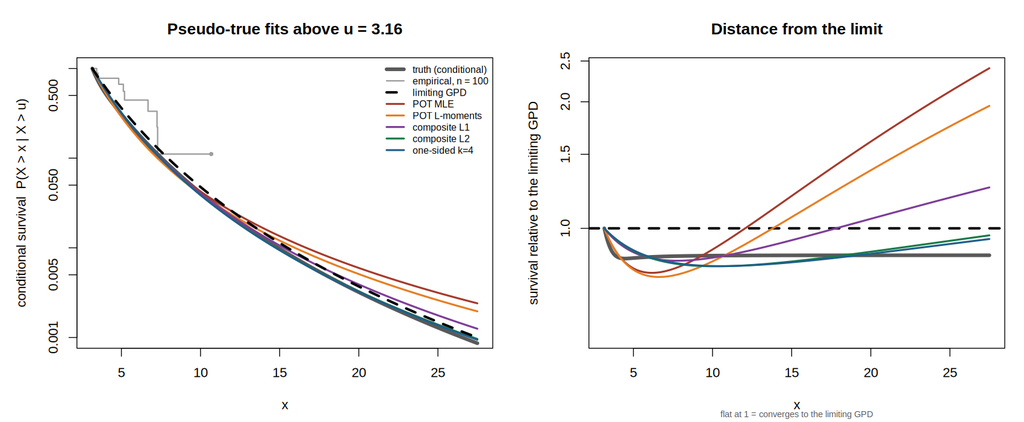

**Pseudo-true GPD limits above u = 3.16**, w(p) = p<sup>6</sup>. Solved from the estimating equation above, not estimated from a sample.

| estimator | scale | shape |
| --- | --- | --- |
| POT maximum likelihood | 1.1933 | 0.3459 |
| POT L-moments | 1.2011 | 0.3247 |
| composite L1 (quantile) | 1.3804 | 0.2548 |
| composite L2 (expectile) | 1.4100 | 0.2316 |
| α-elastile, α = 0.5 | 1.4090 | 0.2326 |
| one-sided, k = 4 | 1.4176 | 0.2291 |
| limiting GPD (the target) | 1.6323 | 0.2000 |

Three things, and the first corrects an earlier claim in this report. **Maximum likelihood and L-moments do not share a limit**: 0.3459 against 0.3247 in shape. Under correct specification they would coincide, but under misspecification they target different functionals — a Kullback–Leibler projection and a moment match — and generically disagree. The gap is small next to their common distance from 0.2000, so on the figure they sit almost together, but there is no single "pseudo-true GPD" to speak of; each estimator has its own.

Second, **ψ matters, but hardly at all among the losses with a linear part**. The expectile, elastile and one-sided limits fall within 0.003 of each other in shape. The quantile sits 0.023 away, outside that cluster. So the meaningful division is between bounded and unbounded ψ, not among the unbounded ones.

Third, and most usefully, **the weight moves the target monotonically towards the limit**.

Pseudo-true limit of the composite expectile as the weight w(p) = p<sup>m</sup> concentrates. The target approaches the limiting GPD from below as m grows.

| m | 0 | 1 | 2 | 4 | 6 | 10 | 20 | → limit |
| --- | --- | --- | --- | --- | --- | --- | --- | --- |
| scale | 1.313 | 1.346 | 1.367 | 1.394 | 1.410 | 1.430 | 1.455 | 1.632 |
| shape | 0.2637 | 0.2520 | 0.2448 | 0.2365 | 0.2316 | 0.2259 | 0.2195 | 0.2000 |

That is the theoretical justification the method needed. Concentrating the weight drives the pseudo-true target towards the limiting GPD, which is what a tail-weighted criterion is *for*; the finite-sample cost of concentrating it is the trap of section 7, and the tension between the two is what fixes a usable weight.

Matching expectiles helps even with no tail weighting at all

The m = 0 column is a flat weight — no tail focus whatever — and it still lands at shape 0.2637 against maximum likelihood's 0.3459. So roughly half the total movement from 0.346 to 0.200 comes from matching expectiles instead of maximising likelihood, before any weighting is applied. That is worth separating in a write-up, because it is a different argument from the one the method is usually sold on.

The limit is the right shape to aim at, not the right level

The carried-back limiting GPD is *not* the truth's conditional distribution, even asymptotically. Conditioning on X > u sweeps in the body mass the contamination adds at the threshold, so the ratio tends to a constant below one: S<sub>cond</sub>/S<sub>limit</sub> → 1/[S(u)(1 + ξu/σ)<sup>1/ξ</sup>] = **0.8629**, matched numerically to four decimals at x = 50, 200 and 1000. Equivalently the GEV component carries only 0.827 of the truth's survival at u. A POT fit is ultimately judged against the truth, so the limiting GPD is a target for the shape rather than the level, and the composite fits — converging on the limit — overshoot the truth in the far tail by about 15%, against maximum likelihood's factor of nearly three.

## 18The other way to tilt: weighting the likelihood

Section 16 closed on a question this report cannot dodge: if the point is tail-weighted fitting under misspecification, there is already a method for that. Fung's *maximum weighted likelihood estimator* (MWLE) does the tilting inside the likelihood rather than inside a loss, and it is the closest thing in the literature to what is being proposed here. It deserves to be run on the same data, not cited and left alone.

### What MWLE is

Take a weight function w, non-decreasing, bounded away from zero and rising to one, and define a *tilted* density from the model density h:

f(y; θ) = h(y; θ) w(y) / C(θ), C(θ) = ∫ h(u; θ) w(u) du ℓ(θ) = Σ <sub>i</sub> w(y <sub>i</sub>) log h(y <sub>i</sub>; θ) − [Σ <sub>i</sub> w(y <sub>i</sub>)] log C(θ)

The normaliser is what makes this more than heuristic reweighting. Without it, weighting the log-likelihood is just a weighted M-estimator with no probabilistic meaning. With it, ℓ(θ) is a genuine log-likelihood — for the tilted family — so under misspecification the estimator converges to the Kullback–Leibler projection *measured in the tilted metric*. That is precisely a tail-weighted KL projection, and it is the same objective this report has been pursuing by other means.

Bridging the two weight functions

Fung's w acts on the raw value y; the weight used throughout this report acts on the probability level p. The two are made comparable through the quantile transform: set w<sup>Fung</sup>(y) = ε + (1−ε) w(F̂(y)) with F̂ the empirical distribution function, and ε = 10<sup>−3</sup> to meet the positivity requirement. The normaliser is then exact rather than quadrature: with y<sub>(1)</sub> < … < y<sub>(n)</sub> and w<sub>j</sub> = w(j/n) constant between consecutive order statistics, C(θ) = Σ<sub>j=0</sub><sup>n</sup> w<sub>j</sub> [H(y<sub>(j+1)</sub>;θ) − H(y<sub>(j)</sub>;θ)] with the endpoints at 0 and 1. Two checks: with w ≡ 1 the routine reproduces the ordinary MLE to five decimals in both families, and the exact C(θ) matches Monte Carlo integration of ∫hw.

### The GEV study

Same data, same weight w(p) = p<sup>6</sup>, same 2000 replicates at n = 100.

Contaminated truth, max(GEV(0,1,0.2), N(1.5,0.8)). MSE relative to the GEV MLE; below one beats it. Last column is the median fitted shape against a true ξ = 0.2.

| estimator | T = 2 | 10 | 48 | 203 | 529 | 1000 | median ξ̂ |
| --- | --- | --- | --- | --- | --- | --- | --- |
| GEV MLE | 1.00 | 1.00 | 1.00 | 1.00 | 1.00 | 1.00 | 0.054 |
| GEV L-moments | 1.24 | 0.95 | 1.30 | 1.10 | 1.09 | 1.11 | 0.095 |
| **MWLE (Fung)** | 32.50 | 2.19 | 2.62 | 1.24 | 0.96 | 0.86 | 0.224 |
| composite L1 | 2.83 | 0.44 | 1.38 | 1.82 | 3.42 | 5.66 | 0.371 |
| composite L2 | 4.83 | 1.56 | 1.71 | 1.03 | 1.00 | 1.04 | 0.189 |
| α-elastile, α = 0.5 | 1.83 | 0.64 | 1.23 | 0.88 | 0.96 | 1.12 | 0.275 |
| inverted Huber, k = 4 | 6.11 | 1.92 | 1.85 | 1.00 | 0.90 | 0.89 | 0.168 |

It also has the worst body in the table by a factor of five: 32.5× the MLE at T = 2. The cause is structural. Fung's weight multiplies the density pointwise, so at w(p) = p<sup>6</sup> floored at 10<sup>−3</sup> the entire body contributes a thousandth of the tail's influence, and nothing in the objective pins the location. This is the same failure mode the composite estimators have — and it has the same repair, the graft of section 09.

### When nothing is wrong

Exactly correct GEV(0, 1, 0.2), where the MLE is efficient. MSE relative to the GEV MLE.

| estimator | T = 2 | 10 | 48 | 203 | 529 | 1000 | median ξ̂ |
| --- | --- | --- | --- | --- | --- | --- | --- |
| GEV MLE | 1.00 | 1.00 | 1.00 | 1.00 | 1.00 | 1.00 | 0.198 |
| GEV L-moments | 1.05 | 0.95 | 0.94 | 0.98 | 1.01 | 1.03 | 0.184 |
| **MWLE (Fung)** | 43.14 | 3.35 | 1.25 | 1.05 | 1.04 | 1.05 | 0.151 |
| composite L1 | 3.68 | 1.20 | 1.11 | 1.64 | 2.24 | 2.83 | 0.167 |
| composite L2 | 2.03 | 2.03 | 1.30 | 1.28 | 1.31 | 1.32 | 0.095 |
| α-elastile, α = 0.5 | 2.01 | 1.51 | 0.98 | 1.04 | 1.15 | 1.25 | 0.122 |
| inverted Huber, k = 4 | 2.47 | 2.28 | 1.43 | 1.26 | 1.18 | 1.12 | 0.085 |

Read this one carefully. **Beyond T = 48, MWLE's tail premium is 4 to 5%** — close to free — while the composite estimators pay 12 to 32%. Weighting a likelihood keeps much of a likelihood's efficiency; weighting a loss does not. In the GEV setting, then, MWLE gets the larger gain under misspecification *and* pays less for it under correct specification, everywhere except the body — and the body is repairable by grafting for both.

### The GPD study reverses it

The same comparison in the peaks-over-threshold setting of section 13 comes out the other way, and that turns out to be the more informative half.

Contaminated truth, three-parameter GPD fitted to exceedances over the sample 0.90-quantile, all estimators grafted onto an empirical body. MSE relative to POT–MLE(0.90), the practitioner's default.

| estimator | T = 2 | 10 | 48 | 203 | 529 | 1000 |
| --- | --- | --- | --- | --- | --- | --- |
| POT–MLE, u = 0.90 | 1.00 | 1.00 | 1.00 | 1.00 | 1.00 | 1.00 |
| MWLE (Fung) + graft | 0.97 | 1.06 | 0.90 | 0.79 | 0.43 | 0.23 |
| composite L2 + graft | 0.98 | 1.38 | 0.86 | 0.70 | 0.36 | 0.21 |
| **inverted Huber, k = 4 + graft** | 0.98 | 1.49 | 0.89 | 0.66 | 0.33 | 0.18 |

Exactly correct GPD(0, 0.5, 0.2), threshold known, two parameters for every method. MSE relative to the GPD MLE, which is efficient here.

| estimator | T = 2 | 10 | 48 | 203 | 529 | 1000 |
| --- | --- | --- | --- | --- | --- | --- |
| GPD MLE | 1.00 | 1.00 | 1.00 | 1.00 | 1.00 | 1.00 |
| GPD L-moments | 0.95 | 0.97 | 0.89 | 0.86 | 0.84 | 0.83 |
| MWLE (Fung) | 16.34 | 5.24 | 1.17 | 0.99 | 1.01 | 1.03 |
| MWLE (Fung) + graft | 1.31 | 1.42 | 1.04 | 1.26 | 1.38 | 1.41 |
| composite L2 + graft | 1.29 | 1.16 | 0.87 | 0.88 | 0.85 | 0.80 |
| **inverted Huber, k = 4 + graft** | 1.29 | 1.16 | 0.84 | 0.77 | 0.71 | 0.63 |

Two reversals. Under contamination the composite estimators now edge ahead — 0.18 for the inverted Huber against MWLE's 0.23 at T = 1000 — and on *correctly specified* GPD data MWLE buys nothing at all: 0.99 to 1.03 from T = 200 outward, exactly the neutral result a tilted likelihood should give when the untilted one is already efficient, while the inverted Huber reaches 0.63.

Why grafting helps one and hurts the other

MWLE ungrafted has the smaller far-tail error of the two MWLE rows (1.03 against 1.41), which is the opposite of the pattern for every composite estimator, where grafting improves the tail as well as the body. The graft rescales the fitted survival function by its own value at the join, so it inherits the noise in S <sub>θ̂</sub>(u). For MWLE that quantity is badly determined: the weight multiplies the density pointwise and floors at 10<sup>−3</sup>, so essentially nothing in the objective constrains the fit near the 0.90-quantile, and the rescaling divides by a noisy number. The composite criterion, by contrast, still integrates over levels below the join with small but non-zero weight, and its fitted survival there is stable.

### What to take from it

MWLE is the stronger method where the fitting problem is hard — the three-parameter GEV, where the shape is poorly identified and a tilted likelihood's efficiency is worth having. The composite estimators are stronger where the problem is regular — the two-parameter GPD above a known threshold, where a likelihood has no efficiency left to give away and what remains to be won is the choice of *which* discrepancy to minimise. Since the peaks-over-threshold setting is the one flood-frequency practice actually uses, that second regime is the one that matters for the application; but the GEV result is a real limitation and belongs in any honest account.

Where the composite construction still has ground

Three things survive the comparison. MWLE needs the model density in closed form and its normaliser integrated — here exactly, but not in general; the composite estimators need only the model's functional curve, which exists for families with no tractable density. MWLE inherits the likelihood's fragility when the family's support depends on θ, which is the GEV's usual numerical complaint. And its weight, acting on y, has no scale-free reading: w(p) = p<sup>6</sup> means the same thing on any data, w(y) does not, which is why the bridge above had to run through F̂. None of that overturns the GEV efficiency comparison; all of it should appear alongside it.

## 19Does the handover have to be smooth?

Section 09 repairs the composite fit's body by blending it with an empirical body through the same weight w that defined the estimator. That is machinery: a mixture in the survival function, a derivative term, a numerical inversion. The simpler alternative is a *hard graft* — empirical below a join at the v-quantile, the fitted tail above, rescaled so the survival function is continuous:

Ŝ(x) = 1 − F̂<sub>n</sub>(x) x ≤ y <sub>(⌈vn⌉)</sub> Ŝ(x) = (1−v) S <sub>θ̂</sub>(x) / S <sub>θ̂</sub>(u) x > u = y <sub>(⌈vn⌉)</sub>

which is nothing but the standard peaks-over-threshold construction, and continuous by construction at the join. If that already fixes the body, the smooth handover is machinery without a purpose. The two were run on the same 2000 datasets and the same fitted parameters, so the only thing varying is the handover.

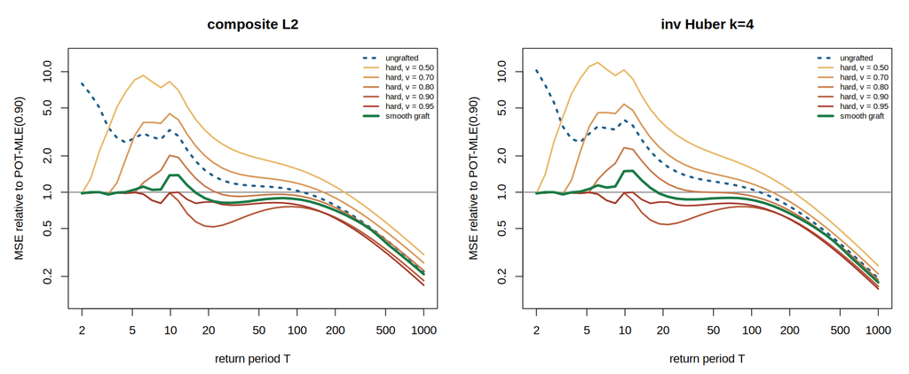

**Five ways to hand over.** MSE relative to POT–MLE(0.90) against return period, for the composite L2 fit (left) and the inverted Huber at k = 4 (right). Dotted blue is the ungrafted fit, the orange-to-red ramp is a hard graft at joins from the 0.50- to the 0.95-quantile, and the thick green line is the smooth graft of section 09. The two darkest hard grafts sit at or below green almost everywhere; the palest is worse than not grafting at all through the five- and ten-year levels.

Contaminated truth, n = 100, MSE relative to POT–MLE(0.90). One tail fit — the inverted Huber at k = 4 — handed over five different ways; the composite-L2 half of the run behaves identically. Below one beats the practitioner's default.

| handover | T = 2 | 5 | 10 | 26 | 48 | 107 | 529 | 1000 |
| --- | --- | --- | --- | --- | --- | --- | --- | --- |
| POT–MLE, u = 0.90 | 1.00 | 1.00 | 1.00 | 1.00 | 1.00 | 1.00 | 1.00 | 1.00 |
| ungrafted | 10.25 | 3.05 | 3.98 | 1.48 | 1.23 | 1.03 | 0.36 | 0.19 |
| hard, v = 0.50 | 0.98 | 11.01 | 10.35 | 2.98 | 2.13 | 1.53 | 0.46 | 0.25 |
| hard, v = 0.70 | 0.98 | 3.48 | 5.38 | 1.83 | 1.43 | 1.15 | 0.39 | 0.21 |
| hard, v = 0.80 | 0.98 | 0.99 | 2.34 | 1.09 | 1.00 | 0.91 | 0.34 | 0.19 |
| **hard, v = 0.90** | 0.98 | 1.00 | 0.99 | 0.55 | 0.69 | 0.75 | 0.30 | 0.17 |
| **hard, v = 0.95** | 0.98 | 1.00 | 0.99 | 0.79 | 0.80 | 0.77 | 0.29 | 0.16 |
| smooth, w = p<sup>6</sup> | 0.98 | 1.06 | 1.49 | 0.89 | 0.89 | 0.85 | 0.33 | 0.18 |

**A hard graft is sufficient, and at v = 0.90 or 0.95 it beats this smooth graft** at every return period in the table, including the far tail (0.16 against 0.18 at T = 1000). It is also brittle in the join: at v = 0.50 the same tail fit is 11× the POT–MLE at the five-year level, worse than not grafting at all, because a hard graft hands the model *all* of the probability above the join and a fit tuned for the 1000-year level has no business describing the five-year one. The smooth graft never does anything like that; its worst number anywhere is 1.49.

What this comparison cannot establish

It is tempting to read the table as hard beating smooth, and that reading is not available. Take the smooth graft's handover weight to the step w(p) = I(p > v) and, with the rescaling folded in, the smooth construction *is* the hard graft at v. The hard grafts are members of the same family, not a rival to it. What the run did was sweep the join over five values while holding the handover weight fixed at one — five members of a family against a sixth — and a family cannot be shown inferior to its own elements. The honest statement is narrower and still useful: **w = p<sup>6</sup> is a poor handover weight**, and the reason is visible below. What a better one buys is a question for the graft work, not for this report.

Where the smooth graft's bump at T = 10 comes from

The green curve's one excursion above the hard grafts is at T ≈ 10, and it is the weight's own doing. The smooth graft gives the fitted tail a share w(p) of the blend, and w(p) = p<sup>6</sup> at p = 0.9 is 0.531 — over half. So at the ten-year level the smooth graft is already majority-model, precisely where the model is worst relative to the empirical distribution, while a hard graft at v = 0.90 gives it exactly zero. The fix, if one wants smoothness, is a sharper weight for the handover than for the fitting; there is no reason the two have to be the same function, and this report used the same one only for tidiness.

One row deserves separate note. Every grafted estimator reads **0.98 at T = 2**, identical to three decimals across five handovers and two tail models. That is not the tail model doing anything — it is the empirical distribution's own performance against POT–MLE(0.90) at the two-year level, which is what any graft must reduce to when the join sits above the point being predicted. The body number in every grafted table in this report should be read that way.

### The practical answer, for now

Use a hard graft at the 0.90–0.95 quantile — not because hard handovers are better, but because it is the only setting in this family that has been tuned. Everything in this report that reports a grafted number uses w = p<sup>6</sup> and is therefore reported against a handover that section 19 has just shown to be poor; the composite estimators' grafted results would improve, not degrade, under a better one.

The question the graft work should answer is not *hard or smooth* — that framing does not survive the nesting above — but *which handover weight*, and whether the optimum is interior. Three things point at an interior optimum: the hard graft's collapse at v = 0.50 shows the step is not uniformly good; its brittleness in v shows the criterion is not flat; and the smooth graft's single excursion sits exactly where the weight hands over too early. A handover family indexed from step to gradual, swept properly, is a small experiment and would settle it.

## 20Extremiles: the same idea in L-space

Every estimator so far has been an M-estimator: a functional defined implicitly as the root of an expectation. *Extremiles* (Daouia, Gijbels and Stupfler) are the other kind — an L-functional, defined explicitly as a weighted integral of the quantile function. They deserve a place here because they were built for exactly the purpose this report is about: a tail-sensitive location functional that is smoother than a quantile and reaches further than an expectile.

Fix τ ∈ (0,1) and set r(τ) = log(½)/log(τ), so r = 1 at τ = ½ and r → ∞ as τ → 1. The extremile is

ξ <sub>τ</sub> = ∫₀¹ J <sub>τ</sub>(t) q <sub>t</sub> dt, J <sub>τ</sub>(t) = r t <sup>r−1</sup>, r = r(τ)

and when r is an integer this is nothing but **the expected maximum of r independent copies** of Y, because r t<sup>r−1</sup> is the density of the largest of r uniforms. That is the whole idea in one line: the τ-extremile of a daily series is the mean annual maximum when r = 365, and the reach into the tail is controlled by how many copies you take the maximum of, not by how far out a probability you name.

### How it sits next to the others

The four families answer the same question — *where is the distribution, seen from the tail?* — with four different notions of "where".

Four ways to ask where a distribution sits, seen from the tail. The first three are M-functionals, defined as roots; the extremile is an L-functional, defined as an integral.

| Family | Defined by | Uses | Tail reach |
| --- | --- | --- | --- |
| Quantile q<sub>p</sub> | E[ p − I(Y<t) ] = 0 | one point of F | all of it, by fiat |
| Expectile e<sub>p</sub> | E[ \|p − I(Y<t)\| (Y−t) ] = 0 | partial means | needs E\|Y\| < ∞ |
| M-quantile (elastile, inv. Huber) | E[ \|p − I(Y<t)\| ψ(Y−t) ] = 0 | partial ψ-means | set by ψ |
| Extremile ξ<sub>τ</sub> | ∫ r t<sup>r−1</sup>q<sub>t</sub> dt, explicit | all of F, polynomially reweighted | needs E\|Y\| < ∞ |

Two structural differences matter. First, the extremile is *explicit*: no root-finding, no estimating equation, and the sample version is a plain linear combination of order statistics with fixed weights — a probability-weighted moment with a tail-tilted kernel. Second, the extremile's weight is on *probability*, whereas ψ reweights on *residual*. The composite construction in this report already weights on probability; extremiles do it inside the functional as well, and stack the two.

Both model families have closed forms. For the GEV the derivation is one line: the maximum of r copies of GEV(μ, σ, ξ) is GEV(μ + σ(r<sup>ξ</sup>−1)/ξ, σr<sup>ξ</sup>, ξ), and taking its mean gives the result. For the GPD the integral is a Beta function.

GEV: ξ <sub>τ</sub> = μ + (σ/ξ) [ r<sup>ξ</sup> Γ(1−ξ) − 1 ] GPD: ξ <sub>τ</sub> = μ + (σ/ξ) [ Γ(r+1) Γ(1−ξ) / Γ(r+1−ξ) − 1 ] (ξ < 1)

Both were checked against numerical integration of J <sub>τ</sub>q<sub>t</sub> to better than 10<sup>−8</sup>, and the "expected maximum of r copies" reading was confirmed by simulation (r = 5, GEV(0,1,0.2): 3.0316 in closed form against 3.0304 from 2×10<sup>6</sup> draws).

### What a composite extremile estimator can and cannot be

The composite estimators in this report all minimise a weighted integral of a *loss*. Extremiles have no such loss to integrate: they are L-functionals, and Newey–Powell-style asymmetric losses do not generate them. So the composite recipe does not transfer. What does transfer is the other half of the idea — matching a whole curve of functionals rather than a likelihood — as **minimum-distance matching on the extremile function**:

θ̂ = argmin <sub>θ</sub> ∫ w(τ) [ ξ̂ <sub>τ</sub> − ξ <sub>τ</sub>(θ) ]² dτ

with ξ̂<sub>τ</sub> = Σ<sub>i</sub> [ (i/n)<sup>r</sup> − ((i−1)/n)<sup>r</sup> ] y<sub>(i)</sub> the empirical extremile. That is a *tail-weighted probability-weighted-moment estimator*, and its honest comparison is not the M-estimator family at all — it is Hosking and Wallis. L-moments match ∫P<sub>k</sub>(t)q<sub>t</sub>dt for the first few shifted Legendre polynomials; this matches ∫r t<sup>r−1</sup>q<sub>t</sub>dt over a continuum of r. Same machinery, tail-tilted kernel.

The reach has to be an intermediate sequence

The obvious grid — run τ up to where r(τ) = n — produces an *inconsistent* estimator, and it took a while to see why. The empirical extremile at r = n puts weight 1 − (1−1/n)<sup>n</sup> ≈ 0.63 on the sample maximum alone, and the sample maximum is a badly biased estimate of E[max of n] for a heavy tail. Measuring that bias directly:

Relative bias of the empirical extremile against the truth, GPD(0, 0.6, 0.25), 20 000 replicates. At fixed r/n the bias does not shrink with n, which is why the reach must be capped by an intermediate sequence.

| relative bias of ξ̂<sub>τ</sub> | r/n = 0.02 | 0.05 | 0.10 | 0.20 | 0.40 | 1.00 |
| --- | --- | --- | --- | --- | --- | --- |
| n = 100 | −0.001 | −0.008 | −0.025 | −0.037 | −0.071 | −0.149 |
| n = 1000 | −0.003 | −0.009 | −0.018 | −0.028 | −0.056 | −0.129 |

The bias at fixed r/n does *not* shrink with n, so the reach must grow slower than the sample: r<sub>max</sub> = αn with α → 0, the same intermediate-sequence condition (k → ∞, k/n → 0) that governs every tail-index estimator. With the cap in place the estimator converges: at n = 10<sup>5</sup>, GPD(0, 0.6, 0.25) recovers (0.615, 0.246), and an α-sweep at n = 2×10<sup>4</sup> runs from (0.618, 0.243) at α = 0.01 to (0.683, 0.205) at α = 1 — the uncapped version's bias, visible.

### What it does

Run on the same data as everything else, with the same w(τ) = τ<sup>6</sup> over the capped grid, and α as the only new knob.

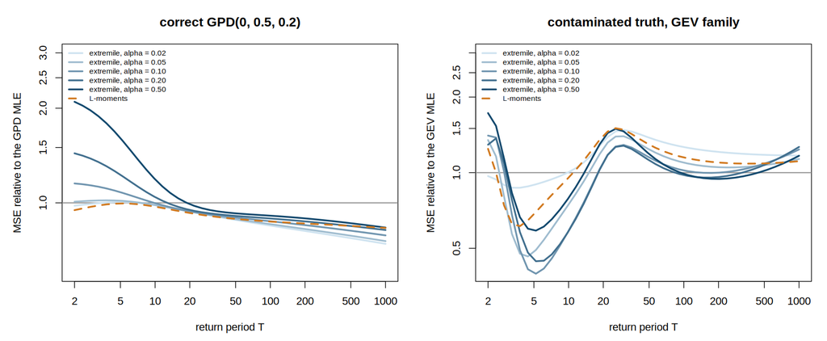

**The reach sweep.** MSE relative to each family's maximum likelihood estimator against return period, for reaches from α = 0.02 (palest) to 0.50 (darkest), with L-moments dashed in orange. Left, a correctly specified GPD: the short reaches sit on L-moments through the body and below it from about T = 30 outward. Right, the contaminated GEV: the ordering reverses, long reaches win the near tail and nothing wins the far tail.

Exactly correct GPD(0, 0.5, 0.2), threshold known, two parameters. MSE relative to the GPD MLE. The two right-hand rows are the M-estimator composites from section 16, ungrafted, for scale.

| estimator | T = 2 | 10 | 48 | 203 | 529 | 1000 | median ξ̂ |
| --- | --- | --- | --- | --- | --- | --- | --- |
| GPD MLE | 1.00 | 1.00 | 1.00 | 1.00 | 1.00 | 1.00 | 0.181 |
| GPD L-moments | 0.95 | 0.97 | 0.89 | 0.86 | 0.84 | 0.83 | 0.195 |
| **extremile, α = 0.02** | 0.98 | 0.99 | 0.88 | 0.81 | 0.77 | 0.74 | — |
| extremile, α = 0.05 | 1.01 | 0.98 | 0.89 | 0.83 | 0.78 | 0.76 | 0.171 |
| extremile, α = 0.20 | 1.44 | 1.05 | 0.91 | 0.87 | 0.84 | 0.82 | 0.146 |
| extremile, α = 0.50 | 2.10 | 1.20 | 0.93 | 0.89 | 0.86 | 0.83 | 0.121 |
| composite L2 | 1.93 | 1.29 | 0.96 | 0.89 | 0.85 | 0.82 | 0.131 |
| inverted Huber, k = 4 | 2.03 | 1.47 | 1.02 | 0.85 | 0.75 | 0.69 | 0.124 |

This is the cleanest result in the report. At α = 0.02 the composite extremile **costs nothing in the body** — 0.98 at the two-year level, marginally better than the MLE rather than 1.9 to 2.0× worse — and still takes 26% off the far-tail MSE. It beats L-moments at every return period from 48 outward while matching it below. No graft, no knot, no weight tuning beyond the reach.

It does not, however, reach the inverted Huber's 0.69, and grafted the inverted Huber goes to 0.63 (section 18). The extremile buys a smaller gain with no risk attached; the M-estimator composites buy a larger one and need a graft to pay for it.

Contaminated truth, GEV family. MSE relative to the GEV MLE, and the median fitted shape against a true ξ = 0.2.

| estimator | T = 2 | 10 | 48 | 203 | 529 | 1000 | median ξ̂ |
| --- | --- | --- | --- | --- | --- | --- | --- |
| GEV MLE | 1.00 | 1.00 | 1.00 | 1.00 | 1.00 | 1.00 | 0.054 |
| GEV L-moments | 1.24 | 0.95 | 1.30 | 1.10 | 1.09 | 1.11 | 0.095 |
| extremile, α = 0.02 | 0.97 | 1.00 | 1.39 | 1.21 | 1.18 | 1.17 | — |
| extremile, α = 0.05 | 1.35 | 0.74 | 1.25 | 1.05 | 1.08 | 1.13 | 0.139 |
| extremile, α = 0.10 | 1.41 | 0.58 | 1.16 | 1.00 | 1.10 | 1.24 | 0.198 |
| extremile, α = 0.20 | 1.29 | 0.58 | 1.13 | 0.96 | 1.09 | 1.27 | 0.224 |
| composite L2 | 4.83 | 1.56 | 1.71 | 1.03 | 1.00 | 1.04 | 0.189 |

α is the whole trade-off

The two tables move in opposite directions in α, and that is the intermediate-sequence condition showing up as a bias–variance choice rather than a theorem. Small α keeps the empirical extremiles nearly unbiased and the estimator efficient, which is what a correctly specified family rewards. Large α pushes the matched functionals out past the contaminated body, which is what misspecification rewards. There is no setting that does both, and unlike the elastile's α there is no interior optimum — the ordering is monotone in each table and simply reversed between them.

### Verdict

The composite extremile is the *safe* member of this family. It is an L-estimator, so it inherits L-moments' good behaviour at small n; it is explicit, so it needs no root-finding and cannot fail to converge; and at a short reach it strictly improves on L-moments in the tail at no cost in the body. What it does not do is deliver the large misspecification gains that motivated this report. Its natural place is as a drop-in replacement for L-moments — a strictly better default — rather than as a competitor to the grafted M-estimator composites.

## 21What level is each estimator actually reading?

Section 17 asked what each estimator converges to. This asks something sharper, and the answer turns out to be the most useful single number in the report. Penultimate approximation gives the language: the extreme-value family is never exactly right at a finite level, and the shape that best describes the data varies with how far out one looks. So a tail-weighted estimator fitted above a low threshold is not doing something the threshold framework cannot express — it is behaving *as if* it had been handed a higher threshold. The question is which one.

The coordinate that makes this precise is the **reciprocal hazard** r(x) = S(x)/f(x). A GPD anchored at u has r(u+y) = σ + ξy exactly: a straight line whose intercept is the scale and whose slope is the shape. So for any distribution, r(x) is the *penultimate scale* at level x and r′(x) the *penultimate shape*, and the ultimate shape is lim r′. Fitting a GPD is fitting a line through r, and every estimator differs only in where along r it reads.

effective threshold: the return period R = 1/S(x <sub>e</sub>) at which r′(x <sub>e</sub>) = ξ* kernel: ξ* = ∫ K(s) r′(u+s) ds, K ≥ 0, ∫K = 1

ξ* is the estimator's pseudo-true shape from section 17, so the effective threshold is where the local penultimate shape equals what the estimator actually returns. The kernel says how that average is taken — which part of the tail the estimator is reading, and how wide a band. It is recovered without assuming the representation holds: perturb r by a smooth *step* at position s, which is a unit-mass bump in r′ there, and K(s) = ∂ξ*/∂ε. A step in r is far better conditioned than a narrow bump in r′, which would need a grid fine enough to resolve it.

The construction is not ours, and it was checked against its source

The method comes from the companion smooth-graft work, where it was applied to maximum likelihood, Stein's weighted composite likelihood and Luceno's AD2R. That code was not reachable from here, so the pipeline was rebuilt from the specification and validated against its numbers, which were produced independently: maximum likelihood's effective threshold comes out **12.7–15.5** against their 13–16, its kernel's 10% point **6.3–6.8** against their 6.5, and LP3(0.6, 0.20) reproduces their 90% point of 142 at **137**. The consistency check they prescribe — the target's own scale against the penultimate GPD at x<sub>e</sub> carried back to u — holds to 4.0% against their 2.5% tolerance, loosening only for the estimators that reach furthest out. Everything below is population-level: quadrature against a known distribution, no Monte Carlo anywhere.

### Where each estimator sits

Seven populations, all fitted above R = 4 (the population 75th percentile). GEV at three shapes, and log-Pearson III — log X ~ Gamma(a, β) — which converges to its limit only logarithmically, at the rate r′(x) = β + β²(a−1)/log x.

Effective threshold, as a return period, for every estimator in this report. The reference values in the third row come from the companion project. Red marks a row reading a *lower* level than maximum likelihood; nothing here is colour-coded as better, because section text below is about why further out is not automatically better. Two further populations — LP3 with β = 0.45 — are omitted and explained at the end.

| estimator | GEV ξ=0 | GEV ξ=0.2 | GEV ξ=0.45 | LP3 (0.6, 0.2) | LP3 (1.6, 0.2) |
| --- | --- | --- | --- | --- | --- |
| POT maximum likelihood | 15.5 | 14.0 | 12.7 | 13.8 | 14.2 |
| POT L-moments | 11.1 | 12.9 | 16.7 | 13.6 | 13.4 |
| — companion project — | WCL (linear weight) 17–22 AD2R 20–24 ADR ~11 |  |  |  |  |
| composite L1, w = 1 | 10.9 | 11.6 | 12.8 | 12.0 | 11.9 |
| composite L1, w = p² | 13.1 | 14.1 | 15.7 | 14.6 | 14.5 |
| composite L1, w = p⁶ | 16.5 | 17.9 | 20.5 | 18.9 | 18.7 |
| composite L1, w = p²⁰ | 24.0 | 26.9 | 32.1 | 29.2 | 28.8 |
| **composite L2, w = 1** | 14.3 | 18.6 | 31.2 | 20.4 | 20.0 |
| composite L2, w = p² | 16.9 | 22.5 | 39.7 | 25.1 | 24.6 |
| **composite L2, w = p⁶** | 20.1 | 27.5 | 51.2 | 31.2 | 30.5 |
| composite L2, w = p²⁰ | 26.0 | 37.3 | 75.8 | 43.9 | 42.6 |
| composite L2, smoothstep p₀=0.50 | 19.1 | 25.8 | 46.6 | 29.1 | 28.5 |
| composite L2, smoothstep p₀=0.90 | 29.7 | 43.2 | 89.3 | 51.6 | 49.8 |
| composite L2, smoothstep p₀=0.95 | 35.9 | 54.1 | 119.9 | 67.1 | 63.8 |
| α-elastile, α=0.5, w = p⁶ | 18.7 | 26.2 | 50.0 | 24.5 | 26.0 |
| inverted Huber, k=1 | 21.9 | 35.0 | 132.0 | 42.0 | 40.3 |
| inverted Huber, k=4 | 20.1 | 29.0 | 77.9 | 33.7 | 32.7 |
| inverted Huber, k=16 | 20.1 | 27.5 | 62.9 | 31.3 | 30.5 |
| MWLE (Fung), w = p² | 26.6 | 23.7 | 21.2 | 24.4 | 24.7 |
| **MWLE (Fung), w = p⁶** | 49.2 | 43.5 | 38.7 | 46.9 | 46.4 |
| composite extremile, r<sub>max</sub>=50 | 27.1 | 34.3 | 50.3 | 39.0 | 38.1 |
| composite extremile, r<sub>max</sub>=200 | 41.3 | 55.8 | 88.7 | 68.4 | 64.9 |

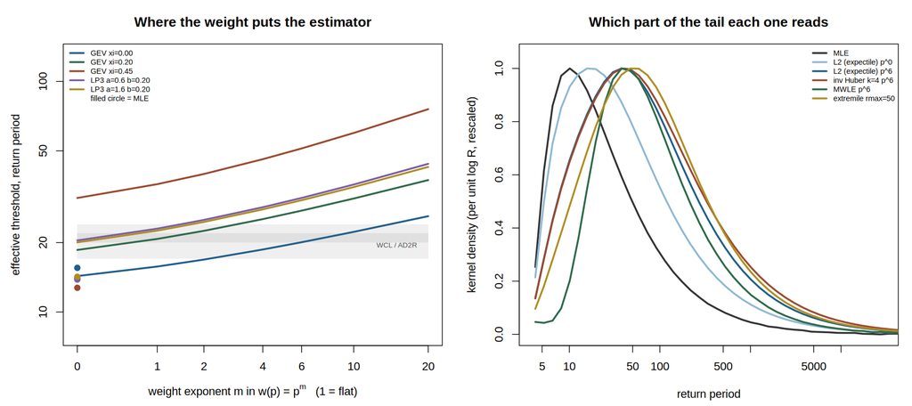

**The reach depends sharply on the tail.** Composite L2 at w = p⁶ runs from 20.1 on a Gumbel tail to 51.2 at ξ = 0.45, and the inverted Huber at k = 1 from 21.9 to 132. The references barely move: maximum likelihood goes 15.5 to 12.7, in the opposite direction. So the effective threshold of a composite estimator is not a property of the estimator alone, and quoting one number for it — as this report has been tempted to do for the weight — would be wrong. The two LP3 populations with β = 0.2 behave like GEV ξ = 0.2 throughout, which is mildly reassuring about how much of this is family-specific.

### Shift, or widen?

Both, and the widening is the cost that the single number hides.

The kernel's quantiles on GEV(0, 1, 0.2), as return periods, with the 90:10 span and the measured total mass. Ordered by effective threshold.

| estimator | R<sub>e</sub> | K 10% | 25% | 50% | 75% | 90% | span | ∫K |
| --- | --- | --- | --- | --- | --- | --- | --- | --- |
| composite L1, w = 1 | 11.6 | 6.1 | 8.4 | 13.9 | 26.8 | 56 | 9 | 1.03 |
| POT maximum likelihood | 14.0 | 6.5 | 9.8 | 19.3 | 50.8 | 158 | 24 | 1.00 |
| composite L1, w = p²⁰ | 26.9 | 10.9 | 20.6 | 43.8 | 98.1 | 219 | 20 | 1.03 |
| composite L2, w = p⁶ | 27.5 | 10.3 | 21.0 | 55.6 | 178 | 649 | 63 | 1.05 |
| inverted Huber, k = 4 | 29.0 | 10.7 | 22.4 | 62.4 | 216 | 852 | 80 | 1.05 |
| inverted Huber, k = 1 | 35.0 | 12.5 | 27.7 | 82.6 | 306 | 1245 | 99 | 1.05 |
| composite L2, w = p²⁰ | 37.3 | 13.3 | 31.3 | 91.7 | 308 | 1145 | 86 | 1.04 |
| **MWLE (Fung), w = p⁶** | 43.5 | 17.4 | 30.3 | 64.8 | 173 | 531 | 30 | 1.01 |
| composite L2, smoothstep p₀=0.95 | 54.1 | 19.0 | 53.4 | 174 | 594 | 2209 | 116 | 1.03 |

The two narrow kernels, and what they explain

**MWLE reaches further than composite L2 at w = p²⁰ — 43.5 against 37.3 — with a span of 30 rather than 86.** Tilting the *likelihood* moves the reading point without smearing it; tilting the *loss* does both. That is very likely the mechanism behind section 18's efficiency result, where MWLE paid a 4–5% premium on a correctly specified GEV against the composites' 12–32%: a narrow kernel is a low-variance kernel. And the pinball loss has the tightest kernel of anything here, 9 at a flat weight and 20 at w = p²⁰ — it simply cannot reach. Narrow-and-near, narrow-and-far, wide-and-far: the three losses are not three points on one dial.

### Is this a cheaper route out than raising the threshold?

The honest comparison, and the one this whole construction exists to make. A composite estimator fitted above R = 4 reads the tail as if handed a threshold at R<sub>e</sub>. Simply raising a hard threshold to R<sub>e</sub> would buy the same bias — and discard most of the sample. Which is cheaper?

Maximum likelihood has an effective threshold of its own, so "the same level" needs care: here R<sub>e</sub> ≈ 3.6 × R<sub>nominal</sub> for the MLE, so the equal-bias competitor to a composite estimator at R<sub>e</sub> = 27.5 is maximum likelihood at a *nominal* threshold of 7.7, not 27.5. Monte Carlo on GEV(0, 1, 0.2), comparing sd(ξ̂):

Where maximum likelihood's sampling standard deviation actually matches each composite estimator's, against the nominal threshold it would need for equal bias. Last column above the equal-bias column means the composite gets to that effective threshold more cheaply — that is, the sd-matched column sitting above the equal-bias column.

| estimator | R<sub>e</sub> | equal-bias MLE nominal R | n = 1000 sd(ξ̂) | n = 1000 sd-matched R | n = 5000 sd(ξ̂) | n = 5000 sd-matched R |
| --- | --- | --- | --- | --- | --- | --- |
| composite L2, w = 1 | 18.6 | 5.2 | 0.082 | 4.6 | 0.039 | 5.4 |
| composite L2, w = p² | 22.5 | 6.3 | 0.088 | 5.2 | 0.043 | 6.6 |
| composite L2, w = p⁶ | 27.5 | 7.7 | 0.095 | 6.0 | 0.049 | 8.3 |
| composite L2, w = p²⁰ | 37.3 | 10.4 | 0.108 | 7.6 | 0.059 | 12.4 |
| inverted Huber, k = 4 | 29.0 | 8.1 | 0.091 | 5.5 | 0.050 | 8.9 |

**At n = 5000 the composite family is the cheaper route; at n = 1000 it is not.** At the larger size every estimator reaches its effective threshold for less variance than raising a hard threshold would — 19% further out at w = p²⁰ — and the margin grows with the weighting, which is the result the method needs.

The n = 1000 row should not be read as a finding about the method, though, because the comparison's premise fails there: at that size none of these estimators is near its asymptotic target, with mean ξ̂ running 0.140 to 0.158 against targets of 0.177 to 0.189. At n = 5000 they are close (0.180 against 0.185) and the matched-bias comparison means what it says. Root mean squared error gives the same verdict at both sizes. The practical reading is that **the effective threshold is an asymptotic statement, and n = 100 — the size this whole report has used — is nowhere near where it becomes true.**

### Two things the construction cannot do here

Non-monotone r′ makes the number meaningless

LP3 with β = 0.45 has a penultimate shape that rises from 0.459 at R = 4 to about 0.480 near R = 20 and then decays back towards 0.45 over the following eight decades. So r′(x) = ξ* has *two* roots for any target inside that window, and 51 of the 52 estimator cells on those two populations report multiple crossings. The kernel is still perfectly well defined; the single summary number is not. This is the ρ = 0 behaviour that makes LP3 worth including, and any effective-threshold table should be read with a monotonicity check attached.

### The variance, in closed form, and what it prices

The effective threshold says where an estimator reads; it says nothing about what that costs. That half is available too, and it turns out to be the same calculation. The criterion's first-order condition makes θ̂ a **Z-estimator**: differentiating the composite criterion, θ̂ solves n<sup>−1</sup>Σ<sub>i</sub> g(Y<sub>i</sub>, θ̂) = 0 with a score that is itself an integral over levels,

g(y, θ) = ∫₀¹ w(p) h <sub>p</sub>(y, θ) ∇ <sub>θ</sub>T <sub>p</sub>(θ) dp, h <sub>p</sub>(y, θ) = |p − I(y < T <sub>p</sub>)| ψ(y − T <sub>p</sub>)

so the ordinary sandwich applies: √n(θ̂ − θ*) → N(0, A<sup>−1</sup>BA<sup>−⊤</sup>), and since E[h<sub>p</sub>(Y, θ)] = g<sub>p</sub><sup>F</sup>(T<sub>p</sub>(θ)), the θ* here is the pseudo-true parameter of section 17 — not a separate object.

A = ∫ w(p)[ c <sub>p</sub> ∇T <sub>p</sub>∇T <sub>p</sub><sup>⊤</sup> − d <sub>p</sub> ∇²T <sub>p</sub> ] dp B = ∫∫ w(p)w(q) κ(p,q) ∇T <sub>p</sub>∇T <sub>q</sub><sup>⊤</sup> dp dq c <sub>p</sub> = E[ |p−I(Y<t <sub>p</sub>)| ψ′(Y−t <sub>p</sub>) ] d <sub>p</sub> = g <sub>p</sub><sup>F</sup>(t <sub>p</sub>) κ(p,q) = E[ h <sub>p</sub>(Y) h <sub>q</sub>(Y) ]

Three readings. The Hessian term carries **d<sub>p</sub>, the same level-by-level discrepancy that defines θ***, so it vanishes identically at a correct model and A collapses to the outer product — misspecification enters the variance through a term that is exactly zero when the family is right. **B is a double integral** whose kernel κ(p,q) is the covariance between the level-p and level-q contributions; for the pinball loss h<sub>p</sub>(y) = p − I(y < t<sub>p</sub>) exactly, so κ reduces at a correct model to min(p,q) − pq, the Brownian bridge. And c<sub>p</sub> is a probability for the smooth losses but a *density* for the pinball one, which is where the differing tail requirements of section 07 come from.

Checked against simulation, not asserted

3000 replicates at three sample sizes, in a correctly specified setting (d<sub>p</sub> = 0) and a misspecified one (max|d<sub>p</sub>| ≈ 7×10<sup>−3</sup>, so the Hessian term is live). Predicted sd of √n ξ̂ against simulated, at n = 8000: pinball **1.420 vs +0.8%** correct and **+0.3%** misspecified; asymmetric square at w = p⁶ **1.808 vs +0.4%** and **+1.9%**; one-sided k = 4 **1.965 vs −0.6%** and **+1.8%**. The correlation between the two components is reproduced as well as the margins (−0.857 predicted, −0.861 observed for L2). The one-sided loss converges far more slowly than the rest — 17% below its asymptotic spread at n = 500, against 8% for L2 and 3% for L1 — which matters for reading a report run at n = 100.

### The reach–efficiency frontier, and two reversals

With the variance in the same closed form as the effective threshold, the two go on one axis. Variance below is on a correctly specified GPD(0, 1, 0.2); reach is on the misspecified GEV tail.

What each unit of reach costs. The asymptotic sd of √n ξ̂ is relative to the GPD MLE's exact 1 + ξ.

| estimator | effective threshold | sd(√n ξ̂) | rel. MLE |
| --- | --- | --- | --- |
| GPD maximum likelihood | 14.0 | 1.200 | 1.00 |
| pinball, w = 1 | 11.6 | 1.315 | 1.10 |
| pinball, w = p⁶ | 17.9 | 1.420 | 1.18 |
| pinball, w = p²⁰ | 26.9 | 1.765 | 1.47 |
| asym. square, w = 1 | 18.6 | 1.384 | 1.15 |
| asym. square, w = p⁶ | 27.5 | 1.808 | 1.51 |
| **asym. square, w = p⁸** | **29.4** | **1.903** | **1.59** |
| asym. square, w = p²⁰ | 37.3 | 2.316 | 1.93 |
| **one-sided, k = 4, w = p⁶** | **29.0** | **1.965** | **1.64** |

Two of this report's findings reverse in the limit

**The pinball loss is asymptotically the more efficient of the two.** At matched weight on GPD(0, 1, 0.2) its sd is 1.420 against the asymmetric square's 1.808, and it is lower for every ξ above about 0.06 — while the asymmetric square's variance diverges as ξ → 1/2 (1.81, 2.62, 4.46, 6.30, 8.64 at ξ = 0.2, 0.3, 0.4, 0.45, 0.49) and the pinball loss's stays bounded (1.42 to 1.88). Section 05's two- to six-fold advantage for L2 is real at n = 100 and gone in the limit.

**The inverted Huber is asymptotically dominated.** At k = 4 it reads the 29.0-year level for sd 1.965; the plain asymmetric square at w = p⁸ reads *further*, 29.4, for 3% less variance. Its asymptotic variance is monotone decreasing in k towards the pure-L2 limit, attained to five decimals by k = 64, so section 15's interior optimum at k = 4 has no asymptotic counterpart at all.

Neither reversal makes the finite-sample results wrong — n = 100 is what a hydrologist has. Both mean the *explanation* offered for them is wrong: what the asymmetric square and the knot buy at n = 100 is finite-sample stability, not a better functional.

## 22What to do with this

**The obstacle is variance, not bias.** Both composite estimators solve the bias problem completely — against a body-contaminated truth they remove a 39% underestimate of the 1000-year level that maximum likelihood cannot. What neither solves on its own is the variance they pay for it.

**Use L2, not L1, whenever the criterion is tail-weighted.** This is the clearest result in the study: two- to six-fold lower far-tail MSE at every weight tested, and a standard deviation that barely moves as the weight changes. In the near-degenerate-body setting it is the difference between beating the MLE on 84% of datasets and losing on 62% of them.

**Put the weight much lower than the quantile reasoning suggests.** Because expectile contamination decays like (1 − p)<sup>ξ</sup> rather than vanishing, restricting an expectile criterion to the extreme tail costs data without buying bias reduction. Here the useful range was p₀ ≈ 0.5–0.8, not 0.95. This is not a detail: it is worth more than any other single choice in the study.

**Mix the losses, with α increasing in the return period.** At a well-placed weight the interior optimum is real and worth 5–23%. Roughly α ≈ 0.2 for T near the record length, rising to pure L2 for T an order of magnitude beyond it.

**Cap the weight at the level of the largest observation**, and **build in the loss-difference form before going near heavy tails**, where the raw L2 criterion is infinite for ξ ≥ 1/2.

**Do not reuse the fitting weight as the handover weight.** Section 19 shows w = p⁶ is a poor handover: a plain hard join at the 0.90-quantile beats it everywhere. It does not show that hard beats smooth — the hard graft is the step member of the same family, and only the join was swept — so the open question is which handover weight is best, not which construction. Until that is settled, a hard join at v ∈ [0.90, 0.95] is the safe default because it is the one setting that has been tuned.

**If nothing but a better default is wanted, use the composite extremile.** At a short reach (α ≈ 0.02) it dominates L-moments on a correctly specified GPD at no cost in the body, is explicit rather than iterative, and cannot fail to converge. It is the only estimator here with no downside to report.

**Quote the effective threshold, not the weight.** Section 21 gives the weight a unit a hydrologist already has. Saying "w = p⁶" conveys nothing; saying "this reads the tail as if the threshold were at the 27-year level, averaging over roughly the 10- to 650-year band" is a statement a reviewer can argue with. Report both numbers, and report the second one — the bandwidth is what the single number hides, and it is where the composite estimators are worst relative to a tilted likelihood.

**Do not choose the weight without knowing ξ.** The same w = p⁶ reads the 20-year level on a Gumbel tail and the 51-year level at ξ = 0.45, while maximum likelihood barely moves (15.5 to 12.7). A weight is not a portable setting, and the effective threshold is the right thing to hold fixed across catchments instead.

### Where the method earns its keep

The contest is governed by (ξ<sub>true</sub> − ξ<sub>MLE</sub>) / sd(ξ̂<sub>composite</sub>), not by the size of the global fit's bias alone. So the method pays off when the truth drags a global fit's shape hard *while leaving a large clean region for the weighted criterion to read* — a sharply concentrated body with a heavy tail, which is a recognisable hydrological situation. It does *not* pay off simply because the tail is heavier: heavier tails inflate the composite estimators' variance at the same rate they inflate the MLE's bias, which is why the grafted setting of section 6 favoured the MLE despite a 55% bias.

### What looks most promising next

- **Reduce the effective number of free parameters over the weighted region.** The loss surface is a near-flat ridge in (μ, σ, ξ): six multi-starts agree to five decimals on a criterion that varies only in the fourth decimal as ξ ranges from −0.15 to +0.45. Almost all of the variance is that ridge, and attacking it directly will do more than any further loss-function tinkering.
- **Correct the mean anchoring.** The L2 bias is entirely the gap between the truth's mean and the model's. Matching the model's expectile function against a mean-corrected empirical target would remove L2's one structural disadvantage against L1.
- **Report the shape parameter, not only the MSE.** At p₀ = 0.5 the expectile fit recovers ξ = 0.209 against a true 0.20 where likelihood returns 0.054. On the question "does the fitted tail have the right heaviness", the two are not close, and an estimator that ties on squared error while getting ξ right is a different and arguably more useful product.
- **Take the kernel seriously as a design object.** Section 21 measures which band of the tail each estimator reads, but nothing here *designs* that band. The obvious question is whether a weight can be chosen to put the kernel where one wants it — a target effective threshold with a target bandwidth — rather than picking w = p⁶ and measuring what happens. MWLE shows a narrow kernel far out is attainable, so the composites' width is not a law.
- **Check the whole thing at the sample size that matters.** The effective threshold is asymptotic, and at n = 100 — this report's own setting — the estimators are nowhere near their targets: at n = 1000 the composite expectile's mean shape is still 0.154 against a target of 0.185. Every statement in section 21 is about a limit that the finite-sample studies never reach, and reconciling the two is the most useful thing left undone here.
- **Settle the MWLE comparison properly.** Section 18 has the two methods splitting the two families — Fung's weighted likelihood ahead on the three-parameter GEV, the composites ahead on the two-parameter GPD. That is one data-generating process each, and the explanation offered (efficiency left on the table in a non-regular problem, none in a regular one) is a hypothesis, not a result. It needs a sweep over ξ, n and contamination type before either claim can be made in print.
- **Chase the extremile's shape recovery.** Under contamination the composite extremile returns a median ξ̂ of 0.198 against a true 0.20, better than anything else here, and still does not win the far tail — the location and scale absorb the contamination instead. An estimator that matched extremiles for the shape and something else for the remaining two parameters is the obvious thing to try next.
- **Choose the loss criterion deliberately.** Squared error at a 1000-year return level is dominated by a handful of replicates. If an occasional overestimate of a design flood is less costly than a systematic underestimate of every one — which in flood frequency it usually is — then median absolute error or a head-to-head win rate is the criterion to optimise, and by those the case for the method is much stronger than by MSE.

## 23Methods and reproducibility

### Machinery

The expectile function of the GEV is needed on a grid of levels inside an optimiser, roughly 10<sup>8</sup> times across the study, so it is computed in closed form rather than numerically. Substituting z = (1 + ξ(t − μ)/σ)<sup>−1/ξ</sup> into the partial moment and integrating by parts gives, for ξ < 1 and ξ ≠ 0,

φ(x) = (σ/ξ) [ Γ<sub>lower</sub>(1 − ξ, z<sub>x</sub>) − (1 − e<sup>−z<sub>x</sub></sup>) z<sub>x</sub><sup>−ξ</sup> ]

with Γ<sub>lower</sub>(s, a) = pgamma(a, s)·Γ(s) — one line in R, exact to machine precision, and about 90× faster than integrating the survival function. The same technique gives the second-order partial moment used to decide when the losses are finite. The expectile itself is then a safeguarded Newton iteration on the identification equation, ported to C++ for the simulation; the R reference implementation is retained and checked against it.

The composite losses are evaluated by cumulative sums over the sorted sample rather than an n×K matrix, which makes them O(K log n) and identical to the direct definition to 10<sup>−15</sup>. Levels are integrated by a composite Gauss-Legendre rule — 24 panels of 8 nodes — under the substitution 1 − p = (1 − p₀)s², which absorbs the unbounded derivative at p = 1 and localises to one panel each the kinks where the fitted functional crosses an observation. Refining the rule further moves a fitted 100-year return level by under 0.15%.

### Checks

Every component is validated in a re-runnable script: the closed-form partial moments against independent numerical integration and against endpoint and derivative identities; the expectile solver against its own identification equation, against the R/C++ pair, and against the `distionary` package; the fast losses against their direct definitions; the quadrature against refinement; the optimiser against multi-start; and the simulated truth against its analytic quantiles and mean.

Optimiser reliability was a live concern, since the composite loss surface is nearly flat. It is not the explanation for anything reported here: five widely separated starts converge to the same point to five decimals for both losses.

### A bug in the reference implementation

Cross-checking turned up a genuine fault in the `expectiles` branch of `probaverse/distionary`. For ξ ≳ 0.5 it returns silently wrong expectiles — for GEV(0, 1, 0.7) at p = 0.7 it gives 5.690 where the answer is 5.129, and the returned values are exactly 2, 8 and 32 times the mean, which are bracket-expansion endpoints rather than roots. The cause is two things combining: `integrate(survival, x, Inf)` fails sporadically on a heavy tail and returns NaN for particular lower limits while neighbouring ones are fine; and the bracketing routine advances on `if (g(hi) <= 0.0) return true;`, where `NaN <= 0` is false, so a single failed integration makes the search step over the root. Recommended fixes: treat a non-finite g as a failure rather than letting it drive the search, and replace the numerical partial moment with the closed form above.